# M507Master_Energy_Consumption_Forecasting_ipynb

```python
!jupyter nbconvert --to html /content/M507Master_Energy_Consumption_Forecasting_ipynb.ipynb
```

```
[NbConvertApp] Converting notebook /content/M507Master_Energy_Consumption_Forecasting_ipynb.ipynb to html
[NbConvertApp] WARNING | Alternative text is missing on 23 image(s).
[NbConvertApp] Writing 3093892 bytes to /content/M507Master_Energy_Consumption_Forecasting_ipynb.html
```

**INTRODUCTION**

UK Electricity Consumption historical from 2009 -2024 data to forecast the demand for year 2025 using timeseries modelling

**OBJECTIVE**

The objective of the project is to analyze the historical electricity demand data and apply time series forecasting methods to predict the electricity demand for three output features i.e. NSD - National System Demand, TSD = Transmission System Demand and England and Wales region in 2025.

**DATASET DETAILS**

https://www.kaggle.com/datasets/albertovidalrod/electricity-consumption-uk-20092022

Historic_demand_year_2009_2024.csv: all the yearly datasets merged in one

The columns in the dataset are:

Settlement_date: date in format dd/mm/yyyy Settlement_period: half hourly period for the historic period

ND (National Demand): It is the sum of metered generation, but excludes generation required to meet station load, pump storage pumping and interconnector exports. Measured in MW.

TSD (Transmission System Demand): It is equal to the ND plus the additional generation required to meet station load, pump storage pumping and interconnector exports. Measured in MW.

England and Wales Demand: As ND above but on an England and Wales basis. Measured in MW.

Embedded_Wind_Capacity: This is National Grid ESO’s best view of the installed embedded wind capacity in GB. Measured in MW

Embedded_Solar_generation: This is an estimate of the GB solar generation from PV panels. Measured in MW.

Embedded_Solar_Capacity: As embedded wind capacity above, but for solar generation. Measured in MW.

non_Bm_Stor: (Non-Balancing Mechanism SHort-Term Operating Reserve). For units that are not included in the ND generator definition. This can be in the form of generation or demand reduction. Measured in MW.

Pump_Storage_pumping The demand due to pumping at hydro pump storage units; the -ve signifies pumping load.

ifa_flow (IFA Interconnector Flow). The flow on on the respective interconnector. -ve signifies export power out from GB; +ve signifies import power into GB. Measured in MW.

ifa2_flow (IFA Interconnector Flow). The flow on the respective interconnector. -ve signifies export power out from GB; +ve signifies import power into GB. Measured in MW.

Moyle_flow (Moyle Interconnector FLow). The flow on the respective interconnector. -ve signifies export power out from GB; +ve signifies import power into GB. Measured in MW.

East_west_flow(East West Innterconnector FLow). The flow on the respective interconnector. -ve signifies export power out from GB; +ve signifies import power into GB. Measured in MW.

Nemo_flow (Nemo Interconnector FLow). The flow on the respective interconnector. -ve signifies export power out from GB; +ve signifies import power into GB. Measured in MW.

```python
# Installing the libraries
import pandas as pd
import numpy as np
import matplotlib.pyplot as plt
import seaborn as sns
import warnings
warnings.filterwarnings('ignore')
import datetime as dt
import tensorflow as tf
import keras
from tensorflow.keras.layers import Lambda, Dense, LSTM, Dropout,Bidirectional,BatchNormalization, InputLayer
from tensorflow.keras.models import Sequential
from tensorflow.keras.optimizers import SGD,Adam
from tensorflow.keras.utils import plot_model
from tensorflow.keras.callbacks import LearningRateScheduler,EarlyStopping,ModelCheckpoint
from sklearn.preprocessing import StandardScaler as sd
from sklearn.model_selection import train_test_split as tts
from sklearn.metrics import mean_squared_error as mse
from sklearn.metrics import mean_absolute_error as mae
from sklearn.metrics import mean_absolute_percentage_error as mape
from tensorflow.keras.models import load_model
```

**Load the dataset**

```python
from google.colab import files

uploaded = files.upload()

for fn in uploaded.keys():
  print('User uploaded file "{name}" with length {length} bytes'.format(
      name=fn, length=len(uploaded[fn])))
```

```
Saving historic_demand_2009_2024.csv to historic_demand_2009_2024.csv
User uploaded file "historic_demand_2009_2024.csv" with length 26379703 bytes
```

**DATA EXPLORATION**

```python
import pandas as pd

# Get the name of the uploaded file
file_name = next(iter(uploaded))

# Read the CSV file into a DataFrame
pdf = pd.read_csv(file_name)

# Display the first few rows to verify
display(pdf.head())
```

|  | Unnamed: 0 | settlement_date | settlement_period | nd | tsd | england_wales_demand | embedded_wind_generation | embedded_wind_capacity | embedded_solar_generation | embedded_solar_capacity | ... | britned_flow | moyle_flow | east_west_flow | nemo_flow | nsl_flow | eleclink_flow | scottish_transfer | viking_flow | greenlink_flow | is_holiday |
| --- | --- | --- | --- | --- | --- | --- | --- | --- | --- | --- | --- | --- | --- | --- | --- | --- | --- | --- | --- | --- | --- |
| 0 | 0 | 2009-01-01 | 1 | 37910 | 38704 | 33939 | 54 | 1403 | 0 | 0 | ... | 0 | -161 | 0 | 0 | NaN | NaN | NaN | NaN | NaN | 1 |
| 1 | 1 | 2009-01-01 | 2 | 38047 | 38964 | 34072 | 53 | 1403 | 0 | 0 | ... | 0 | -160 | 0 | 0 | NaN | NaN | NaN | NaN | NaN | 1 |
| 2 | 2 | 2009-01-01 | 3 | 37380 | 38651 | 33615 | 53 | 1403 | 0 | 0 | ... | 0 | -160 | 0 | 0 | NaN | NaN | NaN | NaN | NaN | 1 |
| 3 | 3 | 2009-01-01 | 4 | 36426 | 37775 | 32526 | 50 | 1403 | 0 | 0 | ... | 0 | -160 | 0 | 0 | NaN | NaN | NaN | NaN | NaN | 1 |
| 4 | 4 | 2009-01-01 | 5 | 35687 | 37298 | 31877 | 50 | 1403 | 0 | 0 | ... | 0 | -160 | 0 | 0 | NaN | NaN | NaN | NaN | NaN | 1 |

5 rows × 24 columns

```python
pdf.info()
```

```
<class 'pandas.core.frame.DataFrame'>
RangeIndex: 279264 entries, 0 to 279263
Data columns (total 24 columns):
 #   Column                     Non-Null Count   Dtype
---  ------                     --------------   -----
 0   Unnamed: 0                 279264 non-null  int64
 1   settlement_date            279264 non-null  object
 2   settlement_period          279264 non-null  int64
 3   nd                         279264 non-null  int64
 4   tsd                        279264 non-null  int64
 5   england_wales_demand       279264 non-null  int64
 6   embedded_wind_generation   279264 non-null  int64
 7   embedded_wind_capacity     279264 non-null  int64
 8   embedded_solar_generation  279264 non-null  int64
 9   embedded_solar_capacity    279264 non-null  int64
```

[output cut: 16 more lines]

```python
pdf.isnull().sum()
```

|  | 0 |
| --- | --- |
| Unnamed: 0 | 0 |
| settlement_date | 0 |
| settlement_period | 0 |
| nd | 0 |
| tsd | 0 |
| england_wales_demand | 0 |
| embedded_wind_generation | 0 |
| embedded_wind_capacity | 0 |
| embedded_solar_generation | 0 |
| embedded_solar_capacity | 0 |
| non_bm_stor | 0 |
| pump_storage_pumping | 0 |
| ifa_flow | 0 |
| ifa2_flow | 0 |
| britned_flow | 0 |
| moyle_flow | 0 |
| east_west_flow | 0 |
| nemo_flow | 0 |
| nsl_flow | 175296 |
| eleclink_flow | 175296 |
| scottish_transfer | 245424 |
| viking_flow | 245424 |
| greenlink_flow | 262944 |
| is_holiday | 0 |

**dtype:** int64

```python
pdf['datetime'] = pd.to_datetime(pdf['settlement_date'])
df = pdf.set_index('datetime')
df = pdf.sort_index()
```

```python
# Ensure the 'settlement_date' column is datetime and set it as the index
df['settlement_date'] = pd.to_datetime(df['settlement_date'])
df = df.set_index('settlement_date')

# Group by settlement_date and calculate the mean for the specified columns
df = df.groupby(df.index)[['nd', 'tsd', 'england_wales_demand','embedded_wind_generation', 'embedded_wind_capacity', 'embedded_solar_generation', 'embedded_solar_capacity', 'non_bm_stor','pump_storage_pumping','is_holiday']].mean()

# Resample the data to a monthly frequency and sum the values
df = df.resample('D').sum()

# Display the first few rows
display(df.head())
```

| settlement_date | nd | tsd | england_wales_demand | embedded_wind_generation | embedded_wind_capacity | embedded_solar_generation | embedded_solar_capacity | non_bm_stor | pump_storage_pumping | is_holiday |
| --- | --- | --- | --- | --- | --- | --- | --- | --- | --- | --- |
| 2009-01-01 | 37277.520833 | 38528.395833 | 33527.729167 | 65.666667 | 1403.0 | 0.0 | 0.0 | 0.000000 | 539.854167 | 1.0 |
| 2009-01-02 | 40015.020833 | 41133.458333 | 36087.083333 | 292.395833 | 1403.0 | 0.0 | 0.0 | 5.354167 | 391.500000 | 0.0 |
| 2009-01-03 | 39535.229167 | 40667.791667 | 35530.187500 | 185.375000 | 1403.0 | 0.0 | 0.0 | 3.145833 | 441.958333 | 0.0 |
| 2009-01-04 | 39820.979167 | 41013.958333 | 35889.770833 | 330.354167 | 1403.0 | 0.0 | 0.0 | 4.625000 | 474.104167 | 0.0 |
| 2009-01-05 | 45450.958333 | 47322.312500 | 41006.854167 | 508.916667 | 1403.0 | 0.0 | 0.0 | 10.125000 | 554.875000 | 0.0 |

As the datset was collected from the year 2009 to 2024, we would take the data from 2020 to 2024 to do time series analysis models to forecast the electricity demand for England Wales for the future year 2025.

Also,as we want to predict the forecast of three demands, slicing the dataset to have only those three columns data as below

```python
df=df.loc['2020-01-01':][['nd','tsd','england_wales_demand']]
df
```

| settlement_date | nd | tsd | england_wales_demand |
| --- | --- | --- | --- |
| 2020-01-01 | 28966.416667 | 29794.395833 | 26636.645833 |
| 2020-01-02 | 30905.062500 | 32376.479167 | 29044.208333 |
| 2020-01-03 | 31908.145833 | 33219.291667 | 29507.020833 |
| 2020-01-04 | 29747.312500 | 31149.437500 | 27515.145833 |
| 2020-01-05 | 29390.104167 | 30473.729167 | 27391.875000 |
| ... | ... | ... | ... |
| 2024-12-01 | 27127.000000 | 29112.520833 | 25067.250000 |
| 2024-12-02 | 31288.333333 | 33033.395833 | 28530.041667 |
| 2024-12-03 | 34013.791667 | 35670.187500 | 30953.645833 |
| 2024-12-04 | 33088.437500 | 36177.104167 | 30461.812500 |
| 2024-12-05 | 30897.416667 | 32973.270833 | 28655.375000 |

1801 rows × 3 columns

```python
df.describe()
```

|  | nd | tsd | england_wales_demand |
| --- | --- | --- | --- |
| count | 1801.000000 | 1801.000000 | 1801.000000 |
| mean | 26854.846434 | 28730.600813 | 24600.170968 |
| std | 4214.856812 | 4159.056929 | 3896.698224 |
| min | 17560.187500 | 19465.666667 | 16450.625000 |
| 25% | 23690.875000 | 25716.562500 | 21652.625000 |
| 50% | 26225.979167 | 28286.000000 | 24055.354167 |
| 75% | 29860.645833 | 31510.520833 | 27466.333333 |
| max | 37587.187500 | 39929.791667 | 34191.979167 |

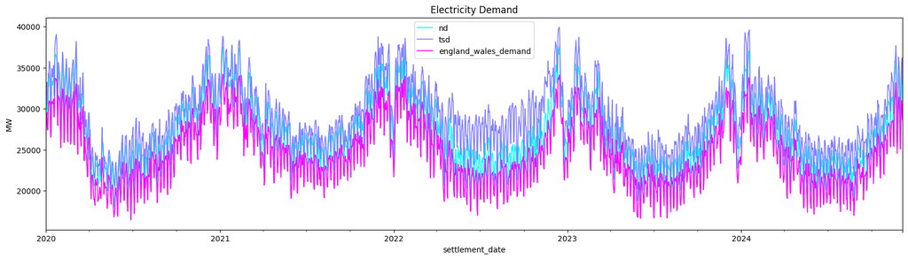

```python
import matplotlib.pyplot as plt
max_month = df.idxmax()
min_month = df.idxmin()
max_value = df.max()
min_value = df.min()
df.plot(figsize=(20,5),linewidth=1.2,cmap='cool',ylabel='MW',title='Electricity Demand')
plt.show()
```

**DATA PREPROCESSING**

```python
#Extract the values in the dataframe into separate variables and reshape into a column vector
nd_data=df['nd'].values.reshape(-1,1)
tsd_data=df['tsd'].values.reshape(-1,1)
ewd_data=df['england_wales_demand'].values.reshape(-1,1)
print(nd_data.shape,tsd_data.shape,ewd_data.shape)
```

```
(1801, 1) (1801, 1) (1801, 1)
```

```python
#Using the scaler transformation for conversion
nd_sd, tsd_sd, ewd_sd=sd(),sd(),sd()
nd_scaler=nd_sd.fit(nd_data)
tsd_scaler=tsd_sd.fit(tsd_data)
ewd_scaler=ewd_sd.fit(ewd_data)
```

```python
# Function to partition data as data blocks for the given time period
def dataset(data,time_steps):
    x,y=[],[]
    for i in range(len(data)-time_steps):
        x.append(data[i:i+time_steps])
        y.append(data[i+time_steps])
    return np.array(x),np.array(y)
```

```python
# In order to keep sequential data monthlywise, keeping the time_steps as 1
time_steps=1
x_nd,y_nd=dataset(nd_scaler.transform(nd_data),time_steps)
x_tsd,y_tsd=dataset(tsd_scaler.transform(tsd_data),time_steps)
x_ewd,y_ewd=dataset(ewd_scaler.transform(ewd_data),time_steps)
x_ewd.shape,y_ewd.shape
```

```
((1800, 1, 1), (1800, 1))
```

```python
# splitting the data as 80/20 for training and testing the model respectively
# splitting the training as 80/20 for train and validation
# Keep shuffle as False not to change the sequence within the blocks
xtrain_nd,xtest_nd,ytrain_nd,ytest_nd=tts(x_nd,y_nd,test_size=0.2,shuffle=False)
xtrain_nd,xval_nd,ytrain_nd,yval_nd=tts(xtrain_nd,ytrain_nd,test_size=0.2,shuffle=False)
xtrain_tsd,xtest_tsd,ytrain_tsd,ytest_tsd=tts(x_tsd,y_tsd,test_size=0.2,shuffle=False)
xtrain_tsd,xval_tsd,ytrain_tsd,yval_tsd=tts(xtrain_tsd,ytrain_tsd,test_size=0.2,shuffle=False)
xtrain_ewd,xtest_ewd,ytrain_ewd,ytest_ewd=tts(x_ewd,y_ewd,test_size=0.2,shuffle=False,)
xtrain_ewd,xval_ewd,ytrain_ewd,yval_ewd=tts(xtrain_ewd,ytrain_ewd,test_size=0.2,shuffle=False,)
```

```python
xtrain_nd.shape,xtest_nd.shape,ytrain_nd.shape,ytest_nd.shape
```

```
((1152, 1, 1), (360, 1, 1), (1152, 1), (360, 1))
```

```python
# As we want to predict based on three features, the total number of input and output features or shape is 3
num_features=3
xtrain_combined = np.concatenate((xtrain_nd, xtrain_tsd, xtrain_ewd), axis=2)
xtrain_combined.shape
```

```
(1152, 1, 3)
```

```python
# Concatenate the target arrays for the single input layer
xval_combined = np.concatenate((xval_nd, xval_tsd, xval_ewd), axis=2)
xval_combined.shape
```

```
(288, 1, 3)
```

```python
# Concatenate the target arrays for the single input layer
xtest_combined = np.concatenate((xtest_nd, xtest_tsd, xtest_ewd), axis=2)
xtest_combined.shape
```

```
(360, 1, 3)
```

```python
  # Concatenate the target arrays for the single output layer
  ytrain_combined = np.concatenate((ytrain_nd, ytrain_tsd, ytrain_ewd), axis=1)
  yval_combined = np.concatenate((yval_nd, yval_tsd, yval_ewd), axis=1)
  ytest_combined = np.concatenate((ytest_nd, ytest_tsd, ytest_ewd), axis=1)
```

```python
ytrain_combined.shape
```

```
(1152, 3)
```

```python
yval_combined.shape
```

```
(288, 3)
```

**MODEL TRAINING FUNCTIONS**

```python
def model_fits(model,model_name,_lr_rate,epoch):
    optimizer=tf.keras.optimizers.Adam(learning_rate=_lr_rate)
    cp4 = ModelCheckpoint('/tmp/ckpt/checkpoint.model.keras', save_best_only=True)
    early_stopping=tf.keras.callbacks.EarlyStopping(monitor='loss',patience=7,verbose=1,restore_best_weights='True',min_delta=0.0001,start_from_epoch=10)
    model.compile(optimizer=optimizer,loss=tf.keras.losses.Huber(),metrics=['mse','mae'])
    history=model.fit(xtrain_combined,y=ytrain_combined,shuffle=False,batch_size=1, validation_data=(xval_combined, yval_combined),
                      epochs=epoch,callbacks=[early_stopping,cp4])
    print('')
    print(f"Model:{model_name}")
    print('')
    print('')

    #plotting the metrics of model- mse-mae and loss function is huber loss( a hybrid of mse and mae as it is regression)
    fig=plt.figure(figsize=(30,10))
    plt.subplot(131)
    plt.plot(history.history['mse'],color='Orange')
    plt.xticks(fontsize='20')
    plt.yticks(fontsize='20')
    plt.title(f'{model_name} - MSE')
    plt.subplot(132)
    plt.plot(history.history['mae'],color='turquoise')
    plt.xticks(fontsize='20')
    plt.yticks(fontsize='20')
    plt.title(f'{model_name} - MAE')
    plt.subplot(133)
    plt.plot(history.history['loss'],color='purple')
    plt.xticks(fontsize='20')
    plt.yticks(fontsize='20')
    #plotting the loss performance of the model at training and test
    fig, ax = plt.subplots(figsize=(8, 4))
    ax.plot(range(1, len(history.history["loss"]) + 1),history.history["loss"],label="training loss",)
    ax.plot(range(1, len(history.history["loss"]) + 1),history.history["val_loss"],label="validation loss",)
    ax.set_xlabel("Epoch")
    ax.set_ylabel("Loss")
    ax.set_title("Loss evaluation")
    ax.legend(loc="best");
    return history,model
```

```python
# Prediction from the model for test set
def predict_withplot_test(model,xtest,timestep=time_steps):
    ypred=model.predict(xtest)
    ypred=np.array(ypred)
    #return ypred
    if len(ypred.shape)==3:
        ypred=ypred.mean(axis=1)
    else:
        pass
    # Dataframe features
    # Extract the index (dates) from the DataFrame slice and use the first and last dates
    test_dates_index = df.index[len(xtrain_nd) + len(xval_combined):len(xtrain_nd) + len(xval_combined) + len(xtest_combined)]
    days=pd.date_range(start=test_dates_index[0],periods=len(xtest),freq='D')
    frame=pd.DataFrame(index=days)

    # Extracting the respective values for the features and taking the inverse transformations from the standardscaler() and adding
    # them for calculating the metrics performances of each model
     #National demand
    nd_=ypred[:,0]
    nd_ypred=np.reshape(nd_,newshape=(-1,1))
    nd_ypred=nd_scaler.inverse_transform(nd_ypred)

    nd_ytest=np.reshape(ytest_nd,newshape=(-1,1))
    nd_ytest=nd_scaler.inverse_transform(nd_ytest)

    frame['nd_ypred']=nd_ypred
    frame['nd_ytest']=nd_ytest

     #Transmission system demand
    tsd_=ypred[:,1]
    tsd_ypred=np.reshape(tsd_,newshape=(-1,1))
    tsd_ypred=tsd_scaler.inverse_transform(tsd_ypred)

    tsd_ytest=np.reshape(ytest_tsd,newshape=(-1,1))
    tsd_ytest=tsd_scaler.inverse_transform(tsd_ytest)

    frame['tsd_ypred']=tsd_ypred
    frame['tsd_ytest']= tsd_ytest

    #England and wales deamand
    ewd_=ypred[:,2]
    ewd_ypred=np.reshape(ewd_,newshape=(-1,1))
    ewd_ypred=ewd_scaler.inverse_transform(ewd_ypred)

    ewd_ytest=np.reshape(ytest_ewd,newshape=(-1,1))
    ewd_ytest=ewd_scaler.inverse_transform(ewd_ytest)

    frame['ewd_ypred']=ewd_ypred
    frame['ewd_ytest']= ewd_ytest

    #plotting area-test vs predicted(in sample)
    fig,axs=plt.subplots(3,1,figsize=(20,10))

    frame[['nd_ypred', 'nd_ytest']].plot(ax=axs[0],color=['red','lime'])
    axs[0].set_title('National Demand - Test Set',fontsize=20)
    axs[0].legend(fontsize='20')

    frame[['tsd_ytest','tsd_ypred']].plot(ax=axs[1],color=['lime','red'])
    axs[1].set_title('Transmission System Demand - Test Set',fontsize=20)
    axs[1].legend(fontsize='20')

    frame[['ewd_ypred','ewd_ytest']].plot(ax=axs[2],color=['red','lime'])
    axs[2].set_title('England and Wales Demand - Test Set',fontsize=20)
    axs[2].legend(fontsize='20')

    for ax in axs:
        ax.tick_params(axis='x', labelsize=15)  # Set x tick label size
        ax.tick_params(axis='y', labelsize=15)
        ax.set_ylabel('Electricity Demand in MV',fontsize='20')
    plt.tight_layout()
    plt.show()
    return frame
```

```python
# Generate evaluation metrics
def metrics (Dataframe):
  metrics=pd.DataFrame()
  frame=Dataframe
  meansq=[]
  sqmeaner=[]
  mean_abs=[]
  mean_abs_p=[]
  for i,j in zip(('nd_ytest','tsd_ytest','ewd_ytest'),('nd_ypred','tsd_ypred','ewd_ypred')):
        meansq.append(mse(frame[i],frame[j]))
        sqmeaner.append(np.sqrt(mse(frame[i],frame[j])))
        mean_abs.append(mae(frame[i],frame[j]))
        mean_abs_p.append(mape(frame[i],frame[j]))
  metrics['Mean Squared Error']=meansq
  metrics['Squared Root (mse)']=sqmeaner
  metrics['Mean Absolute Error']=mean_abs
  metrics['Mean Absolute Percentage Error']=mean_abs_p
  l=['National Demand','Transmission System Demand','England and Wales Demand']
  metrics.index=l
  metrics=metrics.T.round()
  return metrics
```

**Base Model**

```python
base_model = Sequential()
base_model.add(LSTM(units=32, return_sequences=True, activation='relu', input_shape=(xtrain_combined.shape[1], xtrain_combined.shape[2])))
base_model.add(LSTM(units=16, return_sequences=True, activation='relu'))
base_model.add(Dropout(0.2))
base_model.add(LSTM(units=8, return_sequences=True, activation='relu'))
base_model.add(Dense(ytrain_combined.shape[1], activation='linear'))
print(base_model.summary())
```

```
Model: "sequential"
```

```
┏━━━━━━━━━━━━━━━━━━━━━━━━━━━━━━━━━┳━━━━━━━━━━━━━━━━━━━━━━━━┳━━━━━━━━━━━━━━━┓
┃ Layer (type)                    ┃ Output Shape           ┃       Param # ┃
┡━━━━━━━━━━━━━━━━━━━━━━━━━━━━━━━━━╇━━━━━━━━━━━━━━━━━━━━━━━━╇━━━━━━━━━━━━━━━┩
│ lstm (LSTM)                     │ (None, 1, 32)          │         4,608 │
├─────────────────────────────────┼────────────────────────┼───────────────┤
│ lstm_1 (LSTM)                   │ (None, 1, 16)          │         3,136 │
├─────────────────────────────────┼────────────────────────┼───────────────┤
│ dropout (Dropout)               │ (None, 1, 16)          │             0 │
├─────────────────────────────────┼────────────────────────┼───────────────┤
│ lstm_2 (LSTM)                   │ (None, 1, 8)           │           800 │
├─────────────────────────────────┼────────────────────────┼───────────────┤
│ dense (Dense)                   │ (None, 1, 3)           │            27 │
└─────────────────────────────────┴────────────────────────┴───────────────┘
```

```
 Total params: 8,571 (33.48 KB)
```

```
 Trainable params: 8,571 (33.48 KB)
```

```
 Non-trainable params: 0 (0.00 B)
```

```
None
```

```
1152/1152 ━━━━━━━━━━━━━━━━━━━━ 11s 6ms/step - loss: 0.5324 - mae: 0.9341 - mse: 1.2325 - val_loss: 0.4340 - val_mae: 0.8391 - val_mse: 0.9657
1152/1152 ━━━━━━━━━━━━━━━━━━━━ 5s 4ms/step - loss: 0.4727 - mae: 0.8647 - mse: 1.0634 - val_loss: 0.2870 - val_mae: 0.6570 - val_mse: 0.6057
1152/1152 ━━━━━━━━━━━━━━━━━━━━ 6s 5ms/step - loss: 0.2546 - mae: 0.5938 - mse: 0.5360 - val_loss: 0.1640 - val_mae: 0.4767 - val_mse: 0.3344
1152/1152 ━━━━━━━━━━━━━━━━━━━━ 5s 4ms/step - loss: 0.1972 - mae: 0.5118 - mse: 0.4146 - val_loss: 0.1488 - val_mae: 0.4514 - val_mse: 0.3026
1152/1152 ━━━━━━━━━━━━━━━━━━━━ 5s 4ms/step - loss: 0.1855 - mae: 0.4915 - mse: 0.3886 - val_loss: 0.1416 - val_mae: 0.4385 - val_mse: 0.2875
1152/1152 ━━━━━━━━━━━━━━━━━━━━ 6s 5ms/step - loss: 0.1827 - mae: 0.4861 - mse: 0.3766 - val_loss: 0.1371 - val_mae: 0.4303 - val_mse: 0.2780
1152/1152 ━━━━━━━━━━━━━━━━━━━━ 5s 4ms/step - loss: 0.1696 - mae: 0.4671 - mse: 0.3481 - val_loss: 0.1319 - val_mae: 0.4193 - val_mse: 0.2672
1152/1152 ━━━━━━━━━━━━━━━━━━━━ 6s 5ms/step - loss: 0.1714 - mae: 0.4669 - mse: 0.3505 - val_loss: 0.1284 - val_mae: 0.4133 - val_mse: 0.2599
1152/1152 ━━━━━━━━━━━━━━━━━━━━ 5s 4ms/step - loss: 0.1646 - mae: 0.4620 - mse: 0.3365 - val_loss: 0.1248 - val_mae: 0.4078 - val_mse: 0.2526
1152/1152 ━━━━━━━━━━━━━━━━━━━━ 6s 5ms/step - loss: 0.1560 - mae: 0.4438 - mse: 0.3190 - val_loss: 0.1231 - val_mae: 0.4057 - val_mse: 0.2491
1152/1152 ━━━━━━━━━━━━━━━━━━━━ 9s 4ms/step - loss: 0.1501 - mae: 0.4392 - mse: 0.3053 - val_loss: 0.1197 - val_mae: 0.3990 - val_mse: 0.2421
1152/1152 ━━━━━━━━━━━━━━━━━━━━ 7s 6ms/step - loss: 0.1396 - mae: 0.4173 - mse: 0.2848 - val_loss: 0.1178 - val_mae: 0.3953 - val_mse: 0.2381
1152/1152 ━━━━━━━━━━━━━━━━━━━━ 5s 4ms/step - loss: 0.1527 - mae: 0.4343 - mse: 0.3116 - val_loss: 0.1159 - val_mae: 0.3911 - val_mse: 0.2341
1152/1152 ━━━━━━━━━━━━━━━━━━━━ 6s 5ms/step - loss: 0.1468 - mae: 0.4264 - mse: 0.2983 - val_loss: 0.1142 - val_mae: 0.3875 - val_mse: 0.2307
1152/1152 ━━━━━━━━━━━━━━━━━━━━ 9s 4ms/step - loss: 0.1406 - mae: 0.4184 - mse: 0.2856 - val_loss: 0.1133 - val_mae: 0.3854 - val_mse: 0.2289
1152/1152 ━━━━━━━━━━━━━━━━━━━━ 6s 5ms/step - loss: 0.1335 - mae: 0.4091 - mse: 0.2705 - val_loss: 0.1125 - val_mae: 0.3831 - val_mse: 0.2270
1152/1152 ━━━━━━━━━━━━━━━━━━━━ 5s 4ms/step - loss: 0.1410 - mae: 0.4185 - mse: 0.2873 - val_loss: 0.1122 - val_mae: 0.3824 - val_mse: 0.2265
1152/1152 ━━━━━━━━━━━━━━━━━━━━ 6s 5ms/step - loss: 0.1358 - mae: 0.4102 - mse: 0.2752 - val_loss: 0.1122 - val_mae: 0.3816 - val_mse: 0.2264
1152/1152 ━━━━━━━━━━━━━━━━━━━━ 5s 4ms/step - loss: 0.1407 - mae: 0.4216 - mse: 0.2874 - val_loss: 0.1104 - val_mae: 0.3776 - val_mse: 0.2226
1152/1152 ━━━━━━━━━━━━━━━━━━━━ 5s 5ms/step - loss: 0.1291 - mae: 0.4041 - mse: 0.2613 - val_loss: 0.1095 - val_mae: 0.3754 - val_mse: 0.2208
1152/1152 ━━━━━━━━━━━━━━━━━━━━ 9s 4ms/step - loss: 0.1332 - mae: 0.4082 - mse: 0.2692 - val_loss: 0.1095 - val_mae: 0.3750 - val_mse: 0.2207
1152/1152 ━━━━━━━━━━━━━━━━━━━━ 6s 5ms/step - loss: 0.1229 - mae: 0.3904 - mse: 0.2483 - val_loss: 0.1091 - val_mae: 0.3742 - val_mse: 0.2198
1152/1152 ━━━━━━━━━━━━━━━━━━━━ 10s 5ms/step - loss: 0.1304 - mae: 0.4014 - mse: 0.2633 - val_loss: 0.1091 - val_mae: 0.3739 - val_mse: 0.2199
1152/1152 ━━━━━━━━━━━━━━━━━━━━ 5s 4ms/step - loss: 0.1237 - mae: 0.3936 - mse: 0.2495 - val_loss: 0.1092 - val_mae: 0.3738 - val_mse: 0.2201
1152/1152 ━━━━━━━━━━━━━━━━━━━━ 5s 4ms/step - loss: 0.1345 - mae: 0.4128 - mse: 0.2714 - val_loss: 0.1086 - val_mae: 0.3721 - val_mse: 0.2188
1152/1152 ━━━━━━━━━━━━━━━━━━━━ 6s 5ms/step - loss: 0.1234 - mae: 0.3983 - mse: 0.2490 - val_loss: 0.1091 - val_mae: 0.3726 - val_mse: 0.2197
1152/1152 ━━━━━━━━━━━━━━━━━━━━ 5s 4ms/step - loss: 0.1246 - mae: 0.3981 - mse: 0.2518 - val_loss: 0.1102 - val_mae: 0.3742 - val_mse: 0.2221
1152/1152 ━━━━━━━━━━━━━━━━━━━━ 6s 5ms/step - loss: 0.1309 - mae: 0.4071 - mse: 0.2641 - val_loss: 0.1085 - val_mae: 0.3707 - val_mse: 0.2185
1152/1152 ━━━━━━━━━━━━━━━━━━━━ 5s 4ms/step - loss: 0.1276 - mae: 0.4026 - mse: 0.2576 - val_loss: 0.1093 - val_mae: 0.3718 - val_mse: 0.2201
1152/1152 ━━━━━━━━━━━━━━━━━━━━ 5s 4ms/step - loss: 0.1305 - mae: 0.3967 - mse: 0.2657 - val_loss: 0.1099 - val_mae: 0.3726 - val_mse: 0.2213
1152/1152 ━━━━━━━━━━━━━━━━━━━━ 6s 5ms/step - loss: 0.1264 - mae: 0.3986 - mse: 0.2562 - val_loss: 0.1091 - val_mae: 0.3712 - val_mse: 0.2198
1152/1152 ━━━━━━━━━━━━━━━━━━━━ 5s 4ms/step - loss: 0.1297 - mae: 0.4033 - mse: 0.2620 - val_loss: 0.1091 - val_mae: 0.3714 - val_mse: 0.2198
1152/1152 ━━━━━━━━━━━━━━━━━━━━ 6s 5ms/step - loss: 0.1245 - mae: 0.3925 - mse: 0.2517 - val_loss: 0.1096 - val_mae: 0.3719 - val_mse: 0.2207
Epoch 33: early stopping
Restoring model weights from the end of the best epoch: 26.

Model:LSTM
```

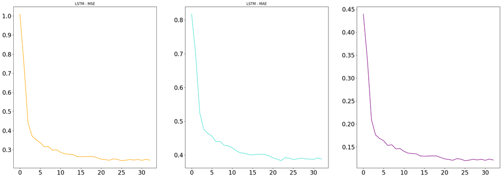

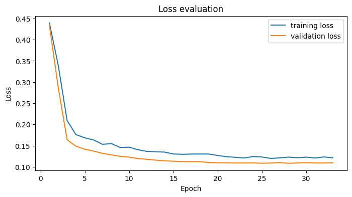

```python
base_history,basemodel=model_fits(base_model,'LSTM',1e-4,50)
```

**Experiment 1 - Change the epoch to 80, no early stopping**

```python
optimizer=tf.keras.optimizers.Adam(learning_rate=1e-4)
model1=base_model.compile(optimizer=optimizer,loss=tf.keras.losses.Huber(),metrics=['mse','mae'])
# Concatenate the target arrays for the single output layer
history1=base_model.fit(xtrain_combined,y=ytrain_combined,shuffle=False,batch_size=1, validation_data=(xval_combined, yval_combined),epochs=80)
print('')
print(f"Model1:")
```

```
1152/1152 ━━━━━━━━━━━━━━━━━━━━ 11s 5ms/step - loss: 0.1238 - mae: 0.3954 - mse: 0.2502 - val_loss: 0.1082 - val_mae: 0.3710 - val_mse: 0.2179
1152/1152 ━━━━━━━━━━━━━━━━━━━━ 5s 4ms/step - loss: 0.1363 - mae: 0.4197 - mse: 0.2762 - val_loss: 0.1110 - val_mae: 0.3753 - val_mse: 0.2238
1152/1152 ━━━━━━━━━━━━━━━━━━━━ 5s 4ms/step - loss: 0.1277 - mae: 0.4011 - mse: 0.2584 - val_loss: 0.1099 - val_mae: 0.3735 - val_mse: 0.2214
1152/1152 ━━━━━━━━━━━━━━━━━━━━ 6s 5ms/step - loss: 0.1249 - mae: 0.3976 - mse: 0.2527 - val_loss: 0.1103 - val_mae: 0.3736 - val_mse: 0.2223
1152/1152 ━━━━━━━━━━━━━━━━━━━━ 5s 4ms/step - loss: 0.1223 - mae: 0.3902 - mse: 0.2464 - val_loss: 0.1096 - val_mae: 0.3721 - val_mse: 0.2209
1152/1152 ━━━━━━━━━━━━━━━━━━━━ 7s 5ms/step - loss: 0.1227 - mae: 0.3926 - mse: 0.2476 - val_loss: 0.1102 - val_mae: 0.3727 - val_mse: 0.2220
1152/1152 ━━━━━━━━━━━━━━━━━━━━ 9s 4ms/step - loss: 0.1235 - mae: 0.3896 - mse: 0.2501 - val_loss: 0.1098 - val_mae: 0.3721 - val_mse: 0.2212
1152/1152 ━━━━━━━━━━━━━━━━━━━━ 6s 5ms/step - loss: 0.1277 - mae: 0.4007 - mse: 0.2578 - val_loss: 0.1101 - val_mae: 0.3725 - val_mse: 0.2218
1152/1152 ━━━━━━━━━━━━━━━━━━━━ 5s 4ms/step - loss: 0.1239 - mae: 0.3926 - mse: 0.2497 - val_loss: 0.1109 - val_mae: 0.3732 - val_mse: 0.2235
1152/1152 ━━━━━━━━━━━━━━━━━━━━ 6s 5ms/step - loss: 0.1257 - mae: 0.3926 - mse: 0.2552 - val_loss: 0.1097 - val_mae: 0.3714 - val_mse: 0.2210
1152/1152 ━━━━━━━━━━━━━━━━━━━━ 5s 4ms/step - loss: 0.1319 - mae: 0.4103 - mse: 0.2673 - val_loss: 0.1104 - val_mae: 0.3723 - val_mse: 0.2224
1152/1152 ━━━━━━━━━━━━━━━━━━━━ 5s 4ms/step - loss: 0.1301 - mae: 0.4025 - mse: 0.2632 - val_loss: 0.1108 - val_mae: 0.3725 - val_mse: 0.2233
1152/1152 ━━━━━━━━━━━━━━━━━━━━ 6s 5ms/step - loss: 0.1247 - mae: 0.3954 - mse: 0.2528 - val_loss: 0.1092 - val_mae: 0.3696 - val_mse: 0.2199
1152/1152 ━━━━━━━━━━━━━━━━━━━━ 5s 4ms/step - loss: 0.1244 - mae: 0.3952 - mse: 0.2516 - val_loss: 0.1103 - val_mae: 0.3714 - val_mse: 0.2221
1152/1152 ━━━━━━━━━━━━━━━━━━━━ 6s 5ms/step - loss: 0.1276 - mae: 0.3953 - mse: 0.2578 - val_loss: 0.1104 - val_mae: 0.3712 - val_mse: 0.2224
1152/1152 ━━━━━━━━━━━━━━━━━━━━ 5s 4ms/step - loss: 0.1248 - mae: 0.3939 - mse: 0.2529 - val_loss: 0.1092 - val_mae: 0.3696 - val_mse: 0.2200
1152/1152 ━━━━━━━━━━━━━━━━━━━━ 5s 5ms/step - loss: 0.1246 - mae: 0.3923 - mse: 0.2520 - val_loss: 0.1108 - val_mae: 0.3717 - val_mse: 0.2231
1152/1152 ━━━━━━━━━━━━━━━━━━━━ 9s 4ms/step - loss: 0.1228 - mae: 0.3883 - mse: 0.2477 - val_loss: 0.1102 - val_mae: 0.3711 - val_mse: 0.2220
1152/1152 ━━━━━━━━━━━━━━━━━━━━ 6s 5ms/step - loss: 0.1252 - mae: 0.3969 - mse: 0.2527 - val_loss: 0.1100 - val_mae: 0.3702 - val_mse: 0.2215
1152/1152 ━━━━━━━━━━━━━━━━━━━━ 10s 5ms/step - loss: 0.1258 - mae: 0.3949 - mse: 0.2542 - val_loss: 0.1096 - val_mae: 0.3698 - val_mse: 0.2206
1152/1152 ━━━━━━━━━━━━━━━━━━━━ 9s 4ms/step - loss: 0.1247 - mae: 0.3948 - mse: 0.2524 - val_loss: 0.1101 - val_mae: 0.3705 - val_mse: 0.2218
1152/1152 ━━━━━━━━━━━━━━━━━━━━ 6s 5ms/step - loss: 0.1236 - mae: 0.3949 - mse: 0.2499 - val_loss: 0.1103 - val_mae: 0.3708 - val_mse: 0.2222
1152/1152 ━━━━━━━━━━━━━━━━━━━━ 5s 4ms/step - loss: 0.1251 - mae: 0.3951 - mse: 0.2535 - val_loss: 0.1107 - val_mae: 0.3714 - val_mse: 0.2230
1152/1152 ━━━━━━━━━━━━━━━━━━━━ 7s 5ms/step - loss: 0.1296 - mae: 0.4030 - mse: 0.2632 - val_loss: 0.1103 - val_mae: 0.3708 - val_mse: 0.2222
1152/1152 ━━━━━━━━━━━━━━━━━━━━ 5s 4ms/step - loss: 0.1285 - mae: 0.3988 - mse: 0.2599 - val_loss: 0.1109 - val_mae: 0.3715 - val_mse: 0.2233
1152/1152 ━━━━━━━━━━━━━━━━━━━━ 5s 5ms/step - loss: 0.1219 - mae: 0.3890 - mse: 0.2462 - val_loss: 0.1096 - val_mae: 0.3695 - val_mse: 0.2207
1152/1152 ━━━━━━━━━━━━━━━━━━━━ 5s 5ms/step - loss: 0.1214 - mae: 0.3880 - mse: 0.2452 - val_loss: 0.1104 - val_mae: 0.3707 - val_mse: 0.2224
1152/1152 ━━━━━━━━━━━━━━━━━━━━ 11s 5ms/step - loss: 0.1223 - mae: 0.3893 - mse: 0.2482 - val_loss: 0.1100 - val_mae: 0.3701 - val_mse: 0.2214
1152/1152 ━━━━━━━━━━━━━━━━━━━━ 5s 4ms/step - loss: 0.1237 - mae: 0.3908 - mse: 0.2500 - val_loss: 0.1096 - val_mae: 0.3691 - val_mse: 0.2206
1152/1152 ━━━━━━━━━━━━━━━━━━━━ 6s 5ms/step - loss: 0.1253 - mae: 0.3949 - mse: 0.2535 - val_loss: 0.1097 - val_mae: 0.3695 - val_mse: 0.2209
1152/1152 ━━━━━━━━━━━━━━━━━━━━ 9s 4ms/step - loss: 0.1255 - mae: 0.3955 - mse: 0.2535 - val_loss: 0.1095 - val_mae: 0.3691 - val_mse: 0.2204
1152/1152 ━━━━━━━━━━━━━━━━━━━━ 6s 5ms/step - loss: 0.1200 - mae: 0.3843 - mse: 0.2421 - val_loss: 0.1104 - val_mae: 0.3702 - val_mse: 0.2224
1152/1152 ━━━━━━━━━━━━━━━━━━━━ 5s 4ms/step - loss: 0.1224 - mae: 0.3874 - mse: 0.2474 - val_loss: 0.1105 - val_mae: 0.3703 - val_mse: 0.2225
1152/1152 ━━━━━━━━━━━━━━━━━━━━ 6s 5ms/step - loss: 0.1216 - mae: 0.3893 - mse: 0.2455 - val_loss: 0.1093 - val_mae: 0.3684 - val_mse: 0.2201
1152/1152 ━━━━━━━━━━━━━━━━━━━━ 5s 4ms/step - loss: 0.1191 - mae: 0.3838 - mse: 0.2403 - val_loss: 0.1103 - val_mae: 0.3699 - val_mse: 0.2221
1152/1152 ━━━━━━━━━━━━━━━━━━━━ 6s 5ms/step - loss: 0.1165 - mae: 0.3779 - mse: 0.2354 - val_loss: 0.1098 - val_mae: 0.3692 - val_mse: 0.2211
1152/1152 ━━━━━━━━━━━━━━━━━━━━ 10s 4ms/step - loss: 0.1206 - mae: 0.3838 - mse: 0.2436 - val_loss: 0.1095 - val_mae: 0.3692 - val_mse: 0.2204
1152/1152 ━━━━━━━━━━━━━━━━━━━━ 6s 5ms/step - loss: 0.1240 - mae: 0.3894 - mse: 0.2511 - val_loss: 0.1102 - val_mae: 0.3701 - val_mse: 0.2219
1152/1152 ━━━━━━━━━━━━━━━━━━━━ 5s 4ms/step - loss: 0.1215 - mae: 0.3855 - mse: 0.2458 - val_loss: 0.1095 - val_mae: 0.3684 - val_mse: 0.2204
1152/1152 ━━━━━━━━━━━━━━━━━━━━ 6s 5ms/step - loss: 0.1238 - mae: 0.3875 - mse: 0.2505 - val_loss: 0.1096 - val_mae: 0.3683 - val_mse: 0.2205
```

[output cut: 27 more lines]

```
1152/1152 ━━━━━━━━━━━━━━━━━━━━ 6s 5ms/step - loss: 0.1183 - mae: 0.3791 - mse: 0.2387 - val_loss: 0.1097 - val_mae: 0.3684 - val_mse: 0.2209
1152/1152 ━━━━━━━━━━━━━━━━━━━━ 5s 4ms/step - loss: 0.1231 - mae: 0.3882 - mse: 0.2485 - val_loss: 0.1105 - val_mae: 0.3703 - val_mse: 0.2225
1152/1152 ━━━━━━━━━━━━━━━━━━━━ 6s 5ms/step - loss: 0.1189 - mae: 0.3818 - mse: 0.2400 - val_loss: 0.1105 - val_mae: 0.3701 - val_mse: 0.2225
1152/1152 ━━━━━━━━━━━━━━━━━━━━ 5s 4ms/step - loss: 0.1218 - mae: 0.3893 - mse: 0.2457 - val_loss: 0.1121 - val_mae: 0.3725 - val_mse: 0.2256
1152/1152 ━━━━━━━━━━━━━━━━━━━━ 6s 5ms/step - loss: 0.1180 - mae: 0.3797 - mse: 0.2380 - val_loss: 0.1097 - val_mae: 0.3685 - val_mse: 0.2208
1152/1152 ━━━━━━━━━━━━━━━━━━━━ 5s 5ms/step - loss: 0.1221 - mae: 0.3882 - mse: 0.2470 - val_loss: 0.1096 - val_mae: 0.3681 - val_mse: 0.2205
1152/1152 ━━━━━━━━━━━━━━━━━━━━ 11s 5ms/step - loss: 0.1239 - mae: 0.3901 - mse: 0.2497 - val_loss: 0.1112 - val_mae: 0.3703 - val_mse: 0.2238
1152/1152 ━━━━━━━━━━━━━━━━━━━━ 5s 4ms/step - loss: 0.1232 - mae: 0.3897 - mse: 0.2491 - val_loss: 0.1100 - val_mae: 0.3686 - val_mse: 0.2214
1152/1152 ━━━━━━━━━━━━━━━━━━━━ 6s 5ms/step - loss: 0.1175 - mae: 0.3770 - mse: 0.2370 - val_loss: 0.1099 - val_mae: 0.3679 - val_mse: 0.2211
1152/1152 ━━━━━━━━━━━━━━━━━━━━ 5s 4ms/step - loss: 0.1236 - mae: 0.3905 - mse: 0.2493 - val_loss: 0.1096 - val_mae: 0.3680 - val_mse: 0.2206
1152/1152 ━━━━━━━━━━━━━━━━━━━━ 5s 4ms/step - loss: 0.1189 - mae: 0.3823 - mse: 0.2402 - val_loss: 0.1111 - val_mae: 0.3703 - val_mse: 0.2237
1152/1152 ━━━━━━━━━━━━━━━━━━━━ 6s 5ms/step - loss: 0.1198 - mae: 0.3838 - mse: 0.2421 - val_loss: 0.1107 - val_mae: 0.3694 - val_mse: 0.2228
1152/1152 ━━━━━━━━━━━━━━━━━━━━ 11s 6ms/step - loss: 0.1180 - mae: 0.3819 - mse: 0.2387 - val_loss: 0.1114 - val_mae: 0.3703 - val_mse: 0.2242

Model1:
```

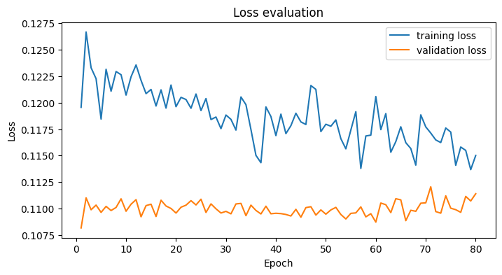

```python
#plotting the loss performance of the model at training and test
fig, ax = plt.subplots(figsize=(8, 4))
ax.plot(range(1, len(history1.history["loss"]) + 1),history1.history["loss"],label="training loss",)
ax.plot(range(1, len(history1.history["loss"]) + 1),history1.history["val_loss"],label="validation loss",)
ax.set_xlabel("Epoch")
ax.set_ylabel("Loss")
ax.set_title("Loss evaluation")
ax.legend(loc="best");
```

**Experiment 2 - Change the learning rate to calculated optimum on the base model using exponential decay scheduling**

```
36/36 ━━━━━━━━━━━━━━━━━━━━ 3s 5ms/step - loss: 0.2483 - mae: 0.5732 - mse: 0.5360 - learning_rate: 1.0000e-07
36/36 ━━━━━━━━━━━━━━━━━━━━ 0s 5ms/step - loss: 0.2490 - mae: 0.5741 - mse: 0.5375 - learning_rate: 1.1220e-07
36/36 ━━━━━━━━━━━━━━━━━━━━ 0s 5ms/step - loss: 0.2480 - mae: 0.5729 - mse: 0.5352 - learning_rate: 1.2589e-07
36/36 ━━━━━━━━━━━━━━━━━━━━ 0s 5ms/step - loss: 0.2475 - mae: 0.5716 - mse: 0.5340 - learning_rate: 1.4125e-07
36/36 ━━━━━━━━━━━━━━━━━━━━ 0s 6ms/step - loss: 0.2495 - mae: 0.5737 - mse: 0.5395 - learning_rate: 1.5849e-07
36/36 ━━━━━━━━━━━━━━━━━━━━ 0s 5ms/step - loss: 0.2463 - mae: 0.5711 - mse: 0.5306 - learning_rate: 1.7783e-07
36/36 ━━━━━━━━━━━━━━━━━━━━ 0s 5ms/step - loss: 0.2461 - mae: 0.5701 - mse: 0.5308 - learning_rate: 1.9953e-07
36/36 ━━━━━━━━━━━━━━━━━━━━ 0s 5ms/step - loss: 0.2457 - mae: 0.5698 - mse: 0.5294 - learning_rate: 2.2387e-07
36/36 ━━━━━━━━━━━━━━━━━━━━ 0s 8ms/step - loss: 0.2494 - mae: 0.5743 - mse: 0.5391 - learning_rate: 2.5119e-07
36/36 ━━━━━━━━━━━━━━━━━━━━ 0s 8ms/step - loss: 0.2472 - mae: 0.5709 - mse: 0.5346 - learning_rate: 2.8184e-07
36/36 ━━━━━━━━━━━━━━━━━━━━ 1s 8ms/step - loss: 0.2475 - mae: 0.5716 - mse: 0.5341 - learning_rate: 3.1623e-07
36/36 ━━━━━━━━━━━━━━━━━━━━ 0s 8ms/step - loss: 0.2477 - mae: 0.5714 - mse: 0.5356 - learning_rate: 3.5481e-07
36/36 ━━━━━━━━━━━━━━━━━━━━ 1s 9ms/step - loss: 0.2477 - mae: 0.5721 - mse: 0.5349 - learning_rate: 3.9811e-07
36/36 ━━━━━━━━━━━━━━━━━━━━ 0s 6ms/step - loss: 0.2488 - mae: 0.5724 - mse: 0.5380 - learning_rate: 4.4668e-07
36/36 ━━━━━━━━━━━━━━━━━━━━ 0s 5ms/step - loss: 0.2493 - mae: 0.5744 - mse: 0.5381 - learning_rate: 5.0119e-07
36/36 ━━━━━━━━━━━━━━━━━━━━ 0s 5ms/step - loss: 0.2498 - mae: 0.5745 - mse: 0.5396 - learning_rate: 5.6234e-07
36/36 ━━━━━━━━━━━━━━━━━━━━ 0s 6ms/step - loss: 0.2453 - mae: 0.5694 - mse: 0.5275 - learning_rate: 6.3096e-07
36/36 ━━━━━━━━━━━━━━━━━━━━ 0s 5ms/step - loss: 0.2474 - mae: 0.5712 - mse: 0.5331 - learning_rate: 7.0795e-07
36/36 ━━━━━━━━━━━━━━━━━━━━ 0s 5ms/step - loss: 0.2475 - mae: 0.5717 - mse: 0.5337 - learning_rate: 7.9433e-07
36/36 ━━━━━━━━━━━━━━━━━━━━ 0s 5ms/step - loss: 0.2476 - mae: 0.5718 - mse: 0.5341 - learning_rate: 8.9125e-07
36/36 ━━━━━━━━━━━━━━━━━━━━ 0s 6ms/step - loss: 0.2486 - mae: 0.5742 - mse: 0.5358 - learning_rate: 1.0000e-06
36/36 ━━━━━━━━━━━━━━━━━━━━ 0s 5ms/step - loss: 0.2484 - mae: 0.5737 - mse: 0.5357 - learning_rate: 1.1220e-06
36/36 ━━━━━━━━━━━━━━━━━━━━ 0s 5ms/step - loss: 0.2466 - mae: 0.5709 - mse: 0.5324 - learning_rate: 1.2589e-06
36/36 ━━━━━━━━━━━━━━━━━━━━ 0s 5ms/step - loss: 0.2494 - mae: 0.5744 - mse: 0.5378 - learning_rate: 1.4125e-06
36/36 ━━━━━━━━━━━━━━━━━━━━ 0s 5ms/step - loss: 0.2491 - mae: 0.5735 - mse: 0.5373 - learning_rate: 1.5849e-06
36/36 ━━━━━━━━━━━━━━━━━━━━ 0s 5ms/step - loss: 0.2488 - mae: 0.5738 - mse: 0.5372 - learning_rate: 1.7783e-06
36/36 ━━━━━━━━━━━━━━━━━━━━ 0s 5ms/step - loss: 0.2462 - mae: 0.5709 - mse: 0.5307 - learning_rate: 1.9953e-06
36/36 ━━━━━━━━━━━━━━━━━━━━ 0s 5ms/step - loss: 0.2496 - mae: 0.5751 - mse: 0.5396 - learning_rate: 2.2387e-06
36/36 ━━━━━━━━━━━━━━━━━━━━ 0s 6ms/step - loss: 0.2480 - mae: 0.5720 - mse: 0.5347 - learning_rate: 2.5119e-06
36/36 ━━━━━━━━━━━━━━━━━━━━ 0s 5ms/step - loss: 0.2482 - mae: 0.5731 - mse: 0.5356 - learning_rate: 2.8184e-06
36/36 ━━━━━━━━━━━━━━━━━━━━ 0s 5ms/step - loss: 0.2475 - mae: 0.5720 - mse: 0.5337 - learning_rate: 3.1623e-06
36/36 ━━━━━━━━━━━━━━━━━━━━ 0s 5ms/step - loss: 0.2485 - mae: 0.5736 - mse: 0.5365 - learning_rate: 3.5481e-06
36/36 ━━━━━━━━━━━━━━━━━━━━ 0s 5ms/step - loss: 0.2483 - mae: 0.5734 - mse: 0.5353 - learning_rate: 3.9811e-06
36/36 ━━━━━━━━━━━━━━━━━━━━ 0s 5ms/step - loss: 0.2490 - mae: 0.5743 - mse: 0.5369 - learning_rate: 4.4668e-06
36/36 ━━━━━━━━━━━━━━━━━━━━ 0s 5ms/step - loss: 0.2461 - mae: 0.5702 - mse: 0.5300 - learning_rate: 5.0119e-06
36/36 ━━━━━━━━━━━━━━━━━━━━ 0s 5ms/step - loss: 0.2452 - mae: 0.5682 - mse: 0.5281 - learning_rate: 5.6234e-06
36/36 ━━━━━━━━━━━━━━━━━━━━ 0s 5ms/step - loss: 0.2495 - mae: 0.5752 - mse: 0.5383 - learning_rate: 6.3096e-06
36/36 ━━━━━━━━━━━━━━━━━━━━ 0s 5ms/step - loss: 0.2453 - mae: 0.5703 - mse: 0.5279 - learning_rate: 7.0795e-06
36/36 ━━━━━━━━━━━━━━━━━━━━ 0s 5ms/step - loss: 0.2455 - mae: 0.5692 - mse: 0.5291 - learning_rate: 7.9433e-06
36/36 ━━━━━━━━━━━━━━━━━━━━ 0s 6ms/step - loss: 0.2469 - mae: 0.5720 - mse: 0.5313 - learning_rate: 8.9125e-06
36/36 ━━━━━━━━━━━━━━━━━━━━ 0s 5ms/step - loss: 0.2480 - mae: 0.5729 - mse: 0.5352 - learning_rate: 1.0000e-05
36/36 ━━━━━━━━━━━━━━━━━━━━ 0s 5ms/step - loss: 0.2459 - mae: 0.5705 - mse: 0.5287 - learning_rate: 1.1220e-05
36/36 ━━━━━━━━━━━━━━━━━━━━ 0s 5ms/step - loss: 0.2423 - mae: 0.5663 - mse: 0.5208 - learning_rate: 1.2589e-05
36/36 ━━━━━━━━━━━━━━━━━━━━ 0s 5ms/step - loss: 0.2456 - mae: 0.5705 - mse: 0.5280 - learning_rate: 1.4125e-05
36/36 ━━━━━━━━━━━━━━━━━━━━ 0s 5ms/step - loss: 0.2437 - mae: 0.5668 - mse: 0.5235 - learning_rate: 1.5849e-05
36/36 ━━━━━━━━━━━━━━━━━━━━ 0s 5ms/step - loss: 0.2475 - mae: 0.5722 - mse: 0.5331 - learning_rate: 1.7783e-05
36/36 ━━━━━━━━━━━━━━━━━━━━ 0s 6ms/step - loss: 0.2433 - mae: 0.5667 - mse: 0.5230 - learning_rate: 1.9953e-05
36/36 ━━━━━━━━━━━━━━━━━━━━ 0s 7ms/step - loss: 0.2430 - mae: 0.5660 - mse: 0.5227 - learning_rate: 2.2387e-05
36/36 ━━━━━━━━━━━━━━━━━━━━ 0s 5ms/step - loss: 0.2463 - mae: 0.5714 - mse: 0.5291 - learning_rate: 2.5119e-05
36/36 ━━━━━━━━━━━━━━━━━━━━ 0s 5ms/step - loss: 0.2435 - mae: 0.5678 - mse: 0.5226 - learning_rate: 2.8184e-05
```

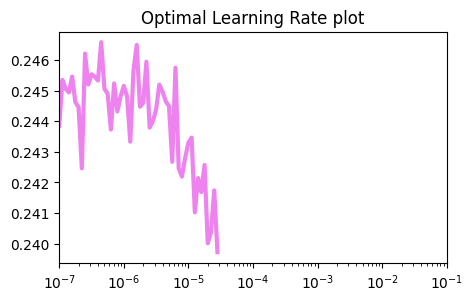

```python
# Change the learning rate to le-7
lr_sched=tf.keras.callbacks.LearningRateScheduler(lambda epoch: 1e-7 * 10**(epoch/20))
opt=tf.keras.optimizers.Adam(learning_rate=1e-7)
history2=base_model.fit(xtrain_combined,y=ytrain_combined,shuffle=False,epochs=50,callbacks=lr_sched)
plt.figure(figsize=(5,3))
plt.semilogx(history2.history['learning_rate'],history2.history['loss'],linewidth=3,color='violet')
plt.title('Optimal Learning Rate plot')
plt.xlim([1e-7, 1e-1])
plt.show()
```

The optimal learning rate found to be le-5 from above and hence train the model with the same rate

```
1152/1152 ━━━━━━━━━━━━━━━━━━━━ 10s 5ms/step - loss: 0.1217 - mae: 0.3872 - mse: 0.2451 - val_loss: 0.1118 - val_mae: 0.3714 - val_mse: 0.2249
1152/1152 ━━━━━━━━━━━━━━━━━━━━ 6s 5ms/step - loss: 0.1245 - mae: 0.3939 - mse: 0.2509 - val_loss: 0.1101 - val_mae: 0.3685 - val_mse: 0.2216
1152/1152 ━━━━━━━━━━━━━━━━━━━━ 10s 5ms/step - loss: 0.1231 - mae: 0.3882 - mse: 0.2485 - val_loss: 0.1087 - val_mae: 0.3662 - val_mse: 0.2187
1152/1152 ━━━━━━━━━━━━━━━━━━━━ 10s 4ms/step - loss: 0.1234 - mae: 0.3901 - mse: 0.2491 - val_loss: 0.1078 - val_mae: 0.3644 - val_mse: 0.2167
1152/1152 ━━━━━━━━━━━━━━━━━━━━ 6s 5ms/step - loss: 0.1217 - mae: 0.3855 - mse: 0.2459 - val_loss: 0.1070 - val_mae: 0.3631 - val_mse: 0.2151
1152/1152 ━━━━━━━━━━━━━━━━━━━━ 5s 4ms/step - loss: 0.1233 - mae: 0.3866 - mse: 0.2491 - val_loss: 0.1065 - val_mae: 0.3624 - val_mse: 0.2142
1152/1152 ━━━━━━━━━━━━━━━━━━━━ 7s 5ms/step - loss: 0.1224 - mae: 0.3858 - mse: 0.2476 - val_loss: 0.1061 - val_mae: 0.3617 - val_mse: 0.2134
1152/1152 ━━━━━━━━━━━━━━━━━━━━ 5s 4ms/step - loss: 0.1214 - mae: 0.3826 - mse: 0.2451 - val_loss: 0.1058 - val_mae: 0.3613 - val_mse: 0.2128
1152/1152 ━━━━━━━━━━━━━━━━━━━━ 6s 5ms/step - loss: 0.1212 - mae: 0.3866 - mse: 0.2444 - val_loss: 0.1054 - val_mae: 0.3607 - val_mse: 0.2120
1152/1152 ━━━━━━━━━━━━━━━━━━━━ 5s 5ms/step - loss: 0.1185 - mae: 0.3817 - mse: 0.2393 - val_loss: 0.1052 - val_mae: 0.3603 - val_mse: 0.2115
1152/1152 ━━━━━━━━━━━━━━━━━━━━ 11s 5ms/step - loss: 0.1222 - mae: 0.3886 - mse: 0.2468 - val_loss: 0.1051 - val_mae: 0.3600 - val_mse: 0.2112
1152/1152 ━━━━━━━━━━━━━━━━━━━━ 10s 5ms/step - loss: 0.1209 - mae: 0.3816 - mse: 0.2460 - val_loss: 0.1049 - val_mae: 0.3598 - val_mse: 0.2109
1152/1152 ━━━━━━━━━━━━━━━━━━━━ 9s 4ms/step - loss: 0.1181 - mae: 0.3780 - mse: 0.2384 - val_loss: 0.1046 - val_mae: 0.3593 - val_mse: 0.2103
1152/1152 ━━━━━━━━━━━━━━━━━━━━ 6s 5ms/step - loss: 0.1230 - mae: 0.3876 - mse: 0.2481 - val_loss: 0.1044 - val_mae: 0.3590 - val_mse: 0.2099
1152/1152 ━━━━━━━━━━━━━━━━━━━━ 10s 5ms/step - loss: 0.1175 - mae: 0.3776 - mse: 0.2369 - val_loss: 0.1044 - val_mae: 0.3589 - val_mse: 0.2097
1152/1152 ━━━━━━━━━━━━━━━━━━━━ 9s 4ms/step - loss: 0.1203 - mae: 0.3821 - mse: 0.2430 - val_loss: 0.1043 - val_mae: 0.3589 - val_mse: 0.2096
1152/1152 ━━━━━━━━━━━━━━━━━━━━ 6s 5ms/step - loss: 0.1204 - mae: 0.3816 - mse: 0.2431 - val_loss: 0.1041 - val_mae: 0.3587 - val_mse: 0.2092
1152/1152 ━━━━━━━━━━━━━━━━━━━━ 10s 5ms/step - loss: 0.1165 - mae: 0.3753 - mse: 0.2354 - val_loss: 0.1040 - val_mae: 0.3584 - val_mse: 0.2090
1152/1152 ━━━━━━━━━━━━━━━━━━━━ 9s 4ms/step - loss: 0.1235 - mae: 0.3903 - mse: 0.2495 - val_loss: 0.1040 - val_mae: 0.3585 - val_mse: 0.2091
1152/1152 ━━━━━━━━━━━━━━━━━━━━ 6s 5ms/step - loss: 0.1206 - mae: 0.3824 - mse: 0.2432 - val_loss: 0.1039 - val_mae: 0.3584 - val_mse: 0.2089
1152/1152 ━━━━━━━━━━━━━━━━━━━━ 5s 4ms/step - loss: 0.1177 - mae: 0.3790 - mse: 0.2378 - val_loss: 0.1039 - val_mae: 0.3583 - val_mse: 0.2088
1152/1152 ━━━━━━━━━━━━━━━━━━━━ 6s 5ms/step - loss: 0.1207 - mae: 0.3837 - mse: 0.2437 - val_loss: 0.1040 - val_mae: 0.3584 - val_mse: 0.2089
1152/1152 ━━━━━━━━━━━━━━━━━━━━ 5s 4ms/step - loss: 0.1168 - mae: 0.3760 - mse: 0.2352 - val_loss: 0.1039 - val_mae: 0.3582 - val_mse: 0.2088
1152/1152 ━━━━━━━━━━━━━━━━━━━━ 5s 4ms/step - loss: 0.1177 - mae: 0.3777 - mse: 0.2372 - val_loss: 0.1039 - val_mae: 0.3582 - val_mse: 0.2087
1152/1152 ━━━━━━━━━━━━━━━━━━━━ 6s 5ms/step - loss: 0.1212 - mae: 0.3813 - mse: 0.2453 - val_loss: 0.1037 - val_mae: 0.3581 - val_mse: 0.2084
Epoch 25: early stopping
Restoring model weights from the end of the best epoch: 18.

Model:LSTM
```

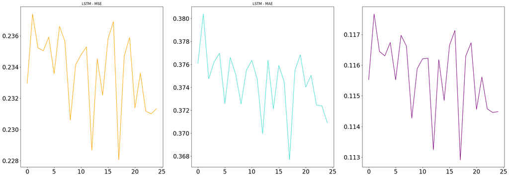

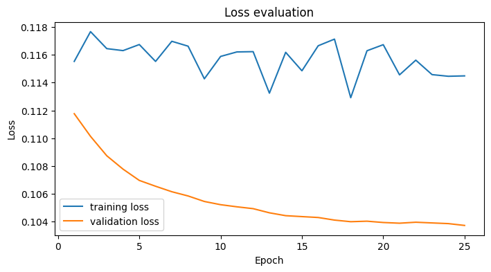

```python
lstm_history2,lstm_model2=model_fits(base_model,'LSTM',1e-5,50)
```

```python
model3 = Sequential()
model3.add(InputLayer((1, 3)))
model3.add(LSTM(64))
model3.add(Dropout(0.2))
model3.add(Dense(8, 'relu'))
model3.add(Dense(3, 'linear'))
model3.summary()
```

```
Model: "sequential_1"
```

```
┏━━━━━━━━━━━━━━━━━━━━━━━━━━━━━━━━━┳━━━━━━━━━━━━━━━━━━━━━━━━┳━━━━━━━━━━━━━━━┓
┃ Layer (type)                    ┃ Output Shape           ┃       Param # ┃
┡━━━━━━━━━━━━━━━━━━━━━━━━━━━━━━━━━╇━━━━━━━━━━━━━━━━━━━━━━━━╇━━━━━━━━━━━━━━━┩
│ lstm_3 (LSTM)                   │ (None, 64)             │        17,408 │
├─────────────────────────────────┼────────────────────────┼───────────────┤
│ dropout_1 (Dropout)             │ (None, 64)             │             0 │
├─────────────────────────────────┼────────────────────────┼───────────────┤
│ dense_1 (Dense)                 │ (None, 8)              │           520 │
├─────────────────────────────────┼────────────────────────┼───────────────┤
│ dense_2 (Dense)                 │ (None, 3)              │            27 │
└─────────────────────────────────┴────────────────────────┴───────────────┘
```

```
 Total params: 17,955 (70.14 KB)
```

```
 Trainable params: 17,955 (70.14 KB)
```

```
 Non-trainable params: 0 (0.00 B)
```

```
1152/1152 ━━━━━━━━━━━━━━━━━━━━ 7s 4ms/step - loss: 0.4960 - mae: 0.8882 - mse: 1.1408 - val_loss: 0.2619 - val_mae: 0.6117 - val_mse: 0.5551
1152/1152 ━━━━━━━━━━━━━━━━━━━━ 4s 3ms/step - loss: 0.2562 - mae: 0.5865 - mse: 0.5427 - val_loss: 0.1412 - val_mae: 0.4231 - val_mse: 0.2868
1152/1152 ━━━━━━━━━━━━━━━━━━━━ 5s 3ms/step - loss: 0.1464 - mae: 0.4277 - mse: 0.2963 - val_loss: 0.1141 - val_mae: 0.3766 - val_mse: 0.2299
1152/1152 ━━━━━━━━━━━━━━━━━━━━ 5s 4ms/step - loss: 0.1265 - mae: 0.3957 - mse: 0.2554 - val_loss: 0.1092 - val_mae: 0.3677 - val_mse: 0.2197
1152/1152 ━━━━━━━━━━━━━━━━━━━━ 4s 3ms/step - loss: 0.1220 - mae: 0.3869 - mse: 0.2469 - val_loss: 0.1075 - val_mae: 0.3653 - val_mse: 0.2164
1152/1152 ━━━━━━━━━━━━━━━━━━━━ 4s 3ms/step - loss: 0.1208 - mae: 0.3841 - mse: 0.2440 - val_loss: 0.1063 - val_mae: 0.3633 - val_mse: 0.2138
1152/1152 ━━━━━━━━━━━━━━━━━━━━ 4s 4ms/step - loss: 0.1172 - mae: 0.3782 - mse: 0.2361 - val_loss: 0.1063 - val_mae: 0.3636 - val_mse: 0.2139
1152/1152 ━━━━━━━━━━━━━━━━━━━━ 4s 3ms/step - loss: 0.1187 - mae: 0.3810 - mse: 0.2396 - val_loss: 0.1060 - val_mae: 0.3629 - val_mse: 0.2131
1152/1152 ━━━━━━━━━━━━━━━━━━━━ 4s 3ms/step - loss: 0.1189 - mae: 0.3791 - mse: 0.2398 - val_loss: 0.1055 - val_mae: 0.3624 - val_mse: 0.2122
1152/1152 ━━━━━━━━━━━━━━━━━━━━ 4s 3ms/step - loss: 0.1155 - mae: 0.3755 - mse: 0.2333 - val_loss: 0.1058 - val_mae: 0.3633 - val_mse: 0.2129
1152/1152 ━━━━━━━━━━━━━━━━━━━━ 4s 4ms/step - loss: 0.1148 - mae: 0.3747 - mse: 0.2313 - val_loss: 0.1061 - val_mae: 0.3637 - val_mse: 0.2134
1152/1152 ━━━━━━━━━━━━━━━━━━━━ 4s 3ms/step - loss: 0.1164 - mae: 0.3745 - mse: 0.2352 - val_loss: 0.1066 - val_mae: 0.3643 - val_mse: 0.2145
1152/1152 ━━━━━━━━━━━━━━━━━━━━ 6s 4ms/step - loss: 0.1198 - mae: 0.3837 - mse: 0.2418 - val_loss: 0.1064 - val_mae: 0.3636 - val_mse: 0.2140
1152/1152 ━━━━━━━━━━━━━━━━━━━━ 4s 3ms/step - loss: 0.1140 - mae: 0.3738 - mse: 0.2297 - val_loss: 0.1065 - val_mae: 0.3642 - val_mse: 0.2142
1152/1152 ━━━━━━━━━━━━━━━━━━━━ 5s 3ms/step - loss: 0.1189 - mae: 0.3827 - mse: 0.2399 - val_loss: 0.1061 - val_mae: 0.3638 - val_mse: 0.2134
1152/1152 ━━━━━━━━━━━━━━━━━━━━ 5s 3ms/step - loss: 0.1144 - mae: 0.3718 - mse: 0.2303 - val_loss: 0.1059 - val_mae: 0.3636 - val_mse: 0.2131
1152/1152 ━━━━━━━━━━━━━━━━━━━━ 4s 3ms/step - loss: 0.1161 - mae: 0.3747 - mse: 0.2344 - val_loss: 0.1054 - val_mae: 0.3626 - val_mse: 0.2121
1152/1152 ━━━━━━━━━━━━━━━━━━━━ 3s 3ms/step - loss: 0.1133 - mae: 0.3676 - mse: 0.2284 - val_loss: 0.1055 - val_mae: 0.3631 - val_mse: 0.2122
1152/1152 ━━━━━━━━━━━━━━━━━━━━ 5s 3ms/step - loss: 0.1151 - mae: 0.3748 - mse: 0.2320 - val_loss: 0.1067 - val_mae: 0.3649 - val_mse: 0.2147
1152/1152 ━━━━━━━━━━━━━━━━━━━━ 4s 3ms/step - loss: 0.1149 - mae: 0.3724 - mse: 0.2318 - val_loss: 0.1057 - val_mae: 0.3637 - val_mse: 0.2127
1152/1152 ━━━━━━━━━━━━━━━━━━━━ 4s 4ms/step - loss: 0.1142 - mae: 0.3739 - mse: 0.2300 - val_loss: 0.1064 - val_mae: 0.3649 - val_mse: 0.2141
1152/1152 ━━━━━━━━━━━━━━━━━━━━ 4s 3ms/step - loss: 0.1158 - mae: 0.3768 - mse: 0.2342 - val_loss: 0.1064 - val_mae: 0.3649 - val_mse: 0.2140
1152/1152 ━━━━━━━━━━━━━━━━━━━━ 5s 3ms/step - loss: 0.1136 - mae: 0.3715 - mse: 0.2284 - val_loss: 0.1061 - val_mae: 0.3642 - val_mse: 0.2135
1152/1152 ━━━━━━━━━━━━━━━━━━━━ 5s 4ms/step - loss: 0.1164 - mae: 0.3731 - mse: 0.2347 - val_loss: 0.1058 - val_mae: 0.3640 - val_mse: 0.2129
1152/1152 ━━━━━━━━━━━━━━━━━━━━ 4s 3ms/step - loss: 0.1136 - mae: 0.3707 - mse: 0.2290 - val_loss: 0.1061 - val_mae: 0.3646 - val_mse: 0.2135
1152/1152 ━━━━━━━━━━━━━━━━━━━━ 5s 3ms/step - loss: 0.1177 - mae: 0.3821 - mse: 0.2367 - val_loss: 0.1065 - val_mae: 0.3655 - val_mse: 0.2143
1152/1152 ━━━━━━━━━━━━━━━━━━━━ 5s 4ms/step - loss: 0.1141 - mae: 0.3746 - mse: 0.2297 - val_loss: 0.1057 - val_mae: 0.3641 - val_mse: 0.2126
1152/1152 ━━━━━━━━━━━━━━━━━━━━ 4s 3ms/step - loss: 0.1138 - mae: 0.3701 - mse: 0.2292 - val_loss: 0.1063 - val_mae: 0.3655 - val_mse: 0.2139
1152/1152 ━━━━━━━━━━━━━━━━━━━━ 4s 3ms/step - loss: 0.1135 - mae: 0.3723 - mse: 0.2288 - val_loss: 0.1063 - val_mae: 0.3655 - val_mse: 0.2140
1152/1152 ━━━━━━━━━━━━━━━━━━━━ 5s 4ms/step - loss: 0.1120 - mae: 0.3697 - mse: 0.2252 - val_loss: 0.1061 - val_mae: 0.3649 - val_mse: 0.2135
1152/1152 ━━━━━━━━━━━━━━━━━━━━ 4s 3ms/step - loss: 0.1188 - mae: 0.3790 - mse: 0.2397 - val_loss: 0.1064 - val_mae: 0.3654 - val_mse: 0.2142
1152/1152 ━━━━━━━━━━━━━━━━━━━━ 4s 3ms/step - loss: 0.1131 - mae: 0.3711 - mse: 0.2278 - val_loss: 0.1063 - val_mae: 0.3654 - val_mse: 0.2139
1152/1152 ━━━━━━━━━━━━━━━━━━━━ 6s 4ms/step - loss: 0.1162 - mae: 0.3775 - mse: 0.2339 - val_loss: 0.1070 - val_mae: 0.3667 - val_mse: 0.2154
1152/1152 ━━━━━━━━━━━━━━━━━━━━ 4s 3ms/step - loss: 0.1141 - mae: 0.3740 - mse: 0.2306 - val_loss: 0.1064 - val_mae: 0.3656 - val_mse: 0.2142
1152/1152 ━━━━━━━━━━━━━━━━━━━━ 3s 3ms/step - loss: 0.1169 - mae: 0.3749 - mse: 0.2361 - val_loss: 0.1064 - val_mae: 0.3659 - val_mse: 0.2142
1152/1152 ━━━━━━━━━━━━━━━━━━━━ 4s 4ms/step - loss: 0.1175 - mae: 0.3778 - mse: 0.2368 - val_loss: 0.1059 - val_mae: 0.3647 - val_mse: 0.2132
1152/1152 ━━━━━━━━━━━━━━━━━━━━ 4s 3ms/step - loss: 0.1145 - mae: 0.3714 - mse: 0.2311 - val_loss: 0.1064 - val_mae: 0.3658 - val_mse: 0.2142
Epoch 37: early stopping
Restoring model weights from the end of the best epoch: 30.

Model:LSTM
```

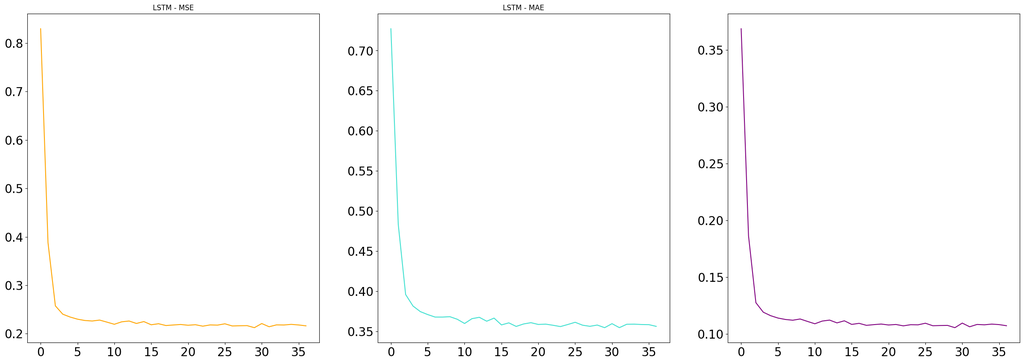

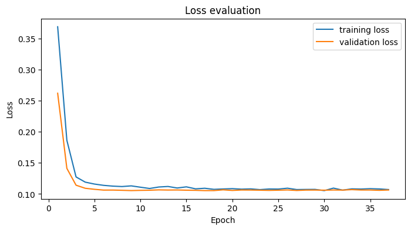

```python
model3_history,model3=model_fits(model3,'LSTM',1e-4,50)
```

**Experiment 4 - Remove the drop outs from base model**

```python
model4 = Sequential()
model4.add(LSTM(units=32, return_sequences=True, activation='relu', input_shape=(xtrain_combined.shape[1], xtrain_combined.shape[2])))
model4.add(LSTM(units=16, return_sequences=True, activation='relu'))
model4.add(LSTM(units=8, return_sequences=True, activation='relu'))
model4.add(Dense(ytrain_combined.shape[1], activation='linear'))
print(model4.summary())
```

```
Model: "sequential_2"
```

```
┏━━━━━━━━━━━━━━━━━━━━━━━━━━━━━━━━━┳━━━━━━━━━━━━━━━━━━━━━━━━┳━━━━━━━━━━━━━━━┓
┃ Layer (type)                    ┃ Output Shape           ┃       Param # ┃
┡━━━━━━━━━━━━━━━━━━━━━━━━━━━━━━━━━╇━━━━━━━━━━━━━━━━━━━━━━━━╇━━━━━━━━━━━━━━━┩
│ lstm_4 (LSTM)                   │ (None, 1, 32)          │         4,608 │
├─────────────────────────────────┼────────────────────────┼───────────────┤
│ lstm_5 (LSTM)                   │ (None, 1, 16)          │         3,136 │
├─────────────────────────────────┼────────────────────────┼───────────────┤
│ lstm_6 (LSTM)                   │ (None, 1, 8)           │           800 │
├─────────────────────────────────┼────────────────────────┼───────────────┤
│ dense_3 (Dense)                 │ (None, 1, 3)           │            27 │
└─────────────────────────────────┴────────────────────────┴───────────────┘
```

```
 Total params: 8,571 (33.48 KB)
```

```
 Trainable params: 8,571 (33.48 KB)
```

```
 Non-trainable params: 0 (0.00 B)
```

```
None
```

```
1152/1152 ━━━━━━━━━━━━━━━━━━━━ 10s 5ms/step - loss: 0.5324 - mae: 0.9340 - mse: 1.2326 - val_loss: 0.4269 - val_mae: 0.8307 - val_mse: 0.9473
1152/1152 ━━━━━━━━━━━━━━━━━━━━ 5s 4ms/step - loss: 0.4423 - mae: 0.8269 - mse: 0.9863 - val_loss: 0.1921 - val_mae: 0.5186 - val_mse: 0.3969
1152/1152 ━━━━━━━━━━━━━━━━━━━━ 6s 5ms/step - loss: 0.2020 - mae: 0.5194 - mse: 0.4186 - val_loss: 0.1660 - val_mae: 0.4705 - val_mse: 0.3436
1152/1152 ━━━━━━━━━━━━━━━━━━━━ 10s 5ms/step - loss: 0.1804 - mae: 0.4871 - mse: 0.3718 - val_loss: 0.1517 - val_mae: 0.4496 - val_mse: 0.3116
1152/1152 ━━━━━━━━━━━━━━━━━━━━ 5s 4ms/step - loss: 0.1666 - mae: 0.4658 - mse: 0.3417 - val_loss: 0.1414 - val_mae: 0.4332 - val_mse: 0.2888
1152/1152 ━━━━━━━━━━━━━━━━━━━━ 5s 4ms/step - loss: 0.1561 - mae: 0.4488 - mse: 0.3190 - val_loss: 0.1335 - val_mae: 0.4202 - val_mse: 0.2714
1152/1152 ━━━━━━━━━━━━━━━━━━━━ 6s 5ms/step - loss: 0.1476 - mae: 0.4346 - mse: 0.3009 - val_loss: 0.1271 - val_mae: 0.4096 - val_mse: 0.2578
1152/1152 ━━━━━━━━━━━━━━━━━━━━ 10s 5ms/step - loss: 0.1408 - mae: 0.4224 - mse: 0.2863 - val_loss: 0.1220 - val_mae: 0.4007 - val_mse: 0.2469
1152/1152 ━━━━━━━━━━━━━━━━━━━━ 9s 4ms/step - loss: 0.1353 - mae: 0.4124 - mse: 0.2745 - val_loss: 0.1179 - val_mae: 0.3930 - val_mse: 0.2382
1152/1152 ━━━━━━━━━━━━━━━━━━━━ 6s 5ms/step - loss: 0.1308 - mae: 0.4042 - mse: 0.2650 - val_loss: 0.1146 - val_mae: 0.3867 - val_mse: 0.2314
1152/1152 ━━━━━━━━━━━━━━━━━━━━ 5s 4ms/step - loss: 0.1272 - mae: 0.3975 - mse: 0.2574 - val_loss: 0.1120 - val_mae: 0.3815 - val_mse: 0.2260
1152/1152 ━━━━━━━━━━━━━━━━━━━━ 6s 5ms/step - loss: 0.1243 - mae: 0.3918 - mse: 0.2514 - val_loss: 0.1101 - val_mae: 0.3776 - val_mse: 0.2221
1152/1152 ━━━━━━━━━━━━━━━━━━━━ 5s 4ms/step - loss: 0.1221 - mae: 0.3873 - mse: 0.2467 - val_loss: 0.1087 - val_mae: 0.3746 - val_mse: 0.2191
1152/1152 ━━━━━━━━━━━━━━━━━━━━ 5s 4ms/step - loss: 0.1203 - mae: 0.3837 - mse: 0.2430 - val_loss: 0.1077 - val_mae: 0.3724 - val_mse: 0.2170
1152/1152 ━━━━━━━━━━━━━━━━━━━━ 6s 5ms/step - loss: 0.1190 - mae: 0.3809 - mse: 0.2401 - val_loss: 0.1069 - val_mae: 0.3707 - val_mse: 0.2154
1152/1152 ━━━━━━━━━━━━━━━━━━━━ 11s 5ms/step - loss: 0.1179 - mae: 0.3789 - mse: 0.2379 - val_loss: 0.1064 - val_mae: 0.3695 - val_mse: 0.2144
1152/1152 ━━━━━━━━━━━━━━━━━━━━ 5s 4ms/step - loss: 0.1171 - mae: 0.3775 - mse: 0.2362 - val_loss: 0.1061 - val_mae: 0.3685 - val_mse: 0.2137
1152/1152 ━━━━━━━━━━━━━━━━━━━━ 5s 5ms/step - loss: 0.1164 - mae: 0.3765 - mse: 0.2349 - val_loss: 0.1059 - val_mae: 0.3678 - val_mse: 0.2132
1152/1152 ━━━━━━━━━━━━━━━━━━━━ 10s 4ms/step - loss: 0.1159 - mae: 0.3757 - mse: 0.2338 - val_loss: 0.1057 - val_mae: 0.3673 - val_mse: 0.2129
1152/1152 ━━━━━━━━━━━━━━━━━━━━ 6s 5ms/step - loss: 0.1156 - mae: 0.3753 - mse: 0.2331 - val_loss: 0.1056 - val_mae: 0.3669 - val_mse: 0.2127
1152/1152 ━━━━━━━━━━━━━━━━━━━━ 10s 5ms/step - loss: 0.1153 - mae: 0.3750 - mse: 0.2325 - val_loss: 0.1056 - val_mae: 0.3667 - val_mse: 0.2127
1152/1152 ━━━━━━━━━━━━━━━━━━━━ 9s 4ms/step - loss: 0.1151 - mae: 0.3748 - mse: 0.2320 - val_loss: 0.1056 - val_mae: 0.3664 - val_mse: 0.2126
1152/1152 ━━━━━━━━━━━━━━━━━━━━ 6s 5ms/step - loss: 0.1149 - mae: 0.3746 - mse: 0.2317 - val_loss: 0.1057 - val_mae: 0.3662 - val_mse: 0.2127
1152/1152 ━━━━━━━━━━━━━━━━━━━━ 10s 5ms/step - loss: 0.1147 - mae: 0.3746 - mse: 0.2314 - val_loss: 0.1057 - val_mae: 0.3661 - val_mse: 0.2128
1152/1152 ━━━━━━━━━━━━━━━━━━━━ 10s 4ms/step - loss: 0.1146 - mae: 0.3745 - mse: 0.2312 - val_loss: 0.1058 - val_mae: 0.3660 - val_mse: 0.2129
1152/1152 ━━━━━━━━━━━━━━━━━━━━ 6s 5ms/step - loss: 0.1146 - mae: 0.3745 - mse: 0.2310 - val_loss: 0.1058 - val_mae: 0.3660 - val_mse: 0.2131
1152/1152 ━━━━━━━━━━━━━━━━━━━━ 5s 4ms/step - loss: 0.1145 - mae: 0.3745 - mse: 0.2308 - val_loss: 0.1059 - val_mae: 0.3659 - val_mse: 0.2132
1152/1152 ━━━━━━━━━━━━━━━━━━━━ 5s 5ms/step - loss: 0.1144 - mae: 0.3746 - mse: 0.2307 - val_loss: 0.1059 - val_mae: 0.3659 - val_mse: 0.2132
1152/1152 ━━━━━━━━━━━━━━━━━━━━ 9s 4ms/step - loss: 0.1144 - mae: 0.3746 - mse: 0.2306 - val_loss: 0.1060 - val_mae: 0.3658 - val_mse: 0.2134
1152/1152 ━━━━━━━━━━━━━━━━━━━━ 6s 5ms/step - loss: 0.1144 - mae: 0.3746 - mse: 0.2306 - val_loss: 0.1060 - val_mae: 0.3658 - val_mse: 0.2134
1152/1152 ━━━━━━━━━━━━━━━━━━━━ 5s 4ms/step - loss: 0.1143 - mae: 0.3746 - mse: 0.2305 - val_loss: 0.1060 - val_mae: 0.3656 - val_mse: 0.2134
1152/1152 ━━━━━━━━━━━━━━━━━━━━ 6s 5ms/step - loss: 0.1143 - mae: 0.3746 - mse: 0.2304 - val_loss: 0.1061 - val_mae: 0.3656 - val_mse: 0.2135
1152/1152 ━━━━━━━━━━━━━━━━━━━━ 9s 4ms/step - loss: 0.1143 - mae: 0.3746 - mse: 0.2304 - val_loss: 0.1061 - val_mae: 0.3656 - val_mse: 0.2136
1152/1152 ━━━━━━━━━━━━━━━━━━━━ 5s 5ms/step - loss: 0.1143 - mae: 0.3746 - mse: 0.2305 - val_loss: 0.1062 - val_mae: 0.3656 - val_mse: 0.2136
1152/1152 ━━━━━━━━━━━━━━━━━━━━ 4s 4ms/step - loss: 0.1143 - mae: 0.3747 - mse: 0.2305 - val_loss: 0.1062 - val_mae: 0.3656 - val_mse: 0.2137
```

[output cut: 18 more lines]

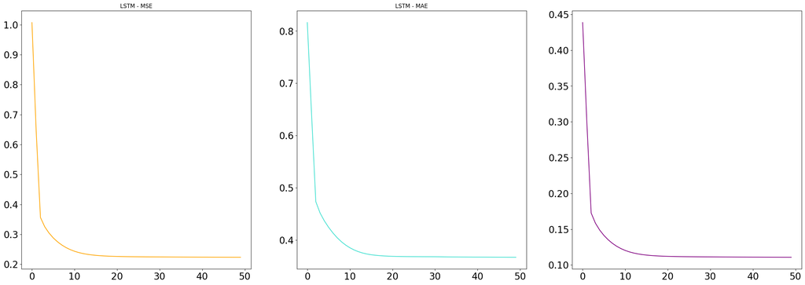

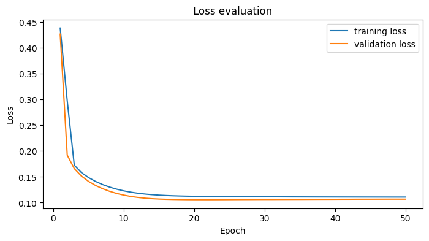

```python
lstm4_history,lstm_model4=model_fits(model4,'LSTM',1e-4,50)
```

```python
model5 = Sequential()
model5.add(LSTM(units=32, return_sequences=True, activation='relu', input_shape=(xtrain_combined.shape[1], xtrain_combined.shape[2])))
model5.add(LSTM(units=16, return_sequences=True, activation='relu'))
model5.add(Dropout(0.2))
model5.add(LSTM(units=8, return_sequences=True, activation='relu'))
model5.add(Dense(ytrain_combined.shape[1], activation='linear'))
print(model5.summary())
```

```
Model: "sequential_3"
```

```
┏━━━━━━━━━━━━━━━━━━━━━━━━━━━━━━━━━┳━━━━━━━━━━━━━━━━━━━━━━━━┳━━━━━━━━━━━━━━━┓
┃ Layer (type)                    ┃ Output Shape           ┃       Param # ┃
┡━━━━━━━━━━━━━━━━━━━━━━━━━━━━━━━━━╇━━━━━━━━━━━━━━━━━━━━━━━━╇━━━━━━━━━━━━━━━┩
│ lstm_7 (LSTM)                   │ (None, 1, 32)          │         4,608 │
├─────────────────────────────────┼────────────────────────┼───────────────┤
│ lstm_8 (LSTM)                   │ (None, 1, 16)          │         3,136 │
├─────────────────────────────────┼────────────────────────┼───────────────┤
│ dropout_2 (Dropout)             │ (None, 1, 16)          │             0 │
├─────────────────────────────────┼────────────────────────┼───────────────┤
│ lstm_9 (LSTM)                   │ (None, 1, 8)           │           800 │
├─────────────────────────────────┼────────────────────────┼───────────────┤
│ dense_4 (Dense)                 │ (None, 1, 3)           │            27 │
└─────────────────────────────────┴────────────────────────┴───────────────┘
```

```
 Total params: 8,571 (33.48 KB)
```

```
 Trainable params: 8,571 (33.48 KB)
```

```
 Non-trainable params: 0 (0.00 B)
```

```
None
```

```
1152/1152 ━━━━━━━━━━━━━━━━━━━━ 10s 4ms/step - loss: 0.5333 - mae: 0.9351 - mse: 1.2352 - val_loss: 0.4371 - val_mae: 0.8426 - val_mse: 0.9743
1152/1152 ━━━━━━━━━━━━━━━━━━━━ 6s 5ms/step - loss: 0.5047 - mae: 0.9017 - mse: 1.1551 - val_loss: 0.3289 - val_mae: 0.7104 - val_mse: 0.7092
1152/1152 ━━━━━━━━━━━━━━━━━━━━ 5s 4ms/step - loss: 0.3326 - mae: 0.6883 - mse: 0.7363 - val_loss: 0.1863 - val_mae: 0.5074 - val_mse: 0.3863
1152/1152 ━━━━━━━━━━━━━━━━━━━━ 5s 4ms/step - loss: 0.2610 - mae: 0.5900 - mse: 0.5617 - val_loss: 0.1690 - val_mae: 0.4826 - val_mse: 0.3472
1152/1152 ━━━━━━━━━━━━━━━━━━━━ 6s 5ms/step - loss: 0.2299 - mae: 0.5535 - mse: 0.4862 - val_loss: 0.1546 - val_mae: 0.4621 - val_mse: 0.3151
1152/1152 ━━━━━━━━━━━━━━━━━━━━ 10s 5ms/step - loss: 0.1980 - mae: 0.5082 - mse: 0.4105 - val_loss: 0.1446 - val_mae: 0.4449 - val_mse: 0.2943
1152/1152 ━━━━━━━━━━━━━━━━━━━━ 5s 4ms/step - loss: 0.1789 - mae: 0.4807 - mse: 0.3674 - val_loss: 0.1378 - val_mae: 0.4335 - val_mse: 0.2800
1152/1152 ━━━━━━━━━━━━━━━━━━━━ 5s 4ms/step - loss: 0.1719 - mae: 0.4734 - mse: 0.3521 - val_loss: 0.1316 - val_mae: 0.4219 - val_mse: 0.2668
1152/1152 ━━━━━━━━━━━━━━━━━━━━ 6s 5ms/step - loss: 0.1595 - mae: 0.4515 - mse: 0.3261 - val_loss: 0.1274 - val_mae: 0.4132 - val_mse: 0.2580
1152/1152 ━━━━━━━━━━━━━━━━━━━━ 11s 5ms/step - loss: 0.1513 - mae: 0.4337 - mse: 0.3118 - val_loss: 0.1236 - val_mae: 0.4067 - val_mse: 0.2501
1152/1152 ━━━━━━━━━━━━━━━━━━━━ 9s 4ms/step - loss: 0.1521 - mae: 0.4362 - mse: 0.3129 - val_loss: 0.1212 - val_mae: 0.4026 - val_mse: 0.2452
1152/1152 ━━━━━━━━━━━━━━━━━━━━ 6s 5ms/step - loss: 0.1494 - mae: 0.4341 - mse: 0.3044 - val_loss: 0.1176 - val_mae: 0.3928 - val_mse: 0.2374
1152/1152 ━━━━━━━━━━━━━━━━━━━━ 5s 4ms/step - loss: 0.1481 - mae: 0.4311 - mse: 0.3030 - val_loss: 0.1164 - val_mae: 0.3924 - val_mse: 0.2351
1152/1152 ━━━━━━━━━━━━━━━━━━━━ 6s 5ms/step - loss: 0.1341 - mae: 0.4101 - mse: 0.2714 - val_loss: 0.1141 - val_mae: 0.3869 - val_mse: 0.2303
1152/1152 ━━━━━━━━━━━━━━━━━━━━ 5s 4ms/step - loss: 0.1457 - mae: 0.4277 - mse: 0.2976 - val_loss: 0.1127 - val_mae: 0.3840 - val_mse: 0.2273
1152/1152 ━━━━━━━━━━━━━━━━━━━━ 5s 4ms/step - loss: 0.1467 - mae: 0.4309 - mse: 0.2983 - val_loss: 0.1133 - val_mae: 0.3859 - val_mse: 0.2288
1152/1152 ━━━━━━━━━━━━━━━━━━━━ 6s 5ms/step - loss: 0.1350 - mae: 0.4097 - mse: 0.2734 - val_loss: 0.1112 - val_mae: 0.3806 - val_mse: 0.2242
1152/1152 ━━━━━━━━━━━━━━━━━━━━ 10s 5ms/step - loss: 0.1380 - mae: 0.4121 - mse: 0.2803 - val_loss: 0.1111 - val_mae: 0.3803 - val_mse: 0.2241
1152/1152 ━━━━━━━━━━━━━━━━━━━━ 5s 4ms/step - loss: 0.1339 - mae: 0.4101 - mse: 0.2709 - val_loss: 0.1131 - val_mae: 0.3839 - val_mse: 0.2283
1152/1152 ━━━━━━━━━━━━━━━━━━━━ 5s 4ms/step - loss: 0.1317 - mae: 0.4060 - mse: 0.2676 - val_loss: 0.1121 - val_mae: 0.3816 - val_mse: 0.2262
1152/1152 ━━━━━━━━━━━━━━━━━━━━ 6s 4ms/step - loss: 0.1431 - mae: 0.4206 - mse: 0.2944 - val_loss: 0.1115 - val_mae: 0.3801 - val_mse: 0.2250
1152/1152 ━━━━━━━━━━━━━━━━━━━━ 11s 5ms/step - loss: 0.1347 - mae: 0.4061 - mse: 0.2726 - val_loss: 0.1129 - val_mae: 0.3820 - val_mse: 0.2279
1152/1152 ━━━━━━━━━━━━━━━━━━━━ 10s 5ms/step - loss: 0.1331 - mae: 0.4043 - mse: 0.2700 - val_loss: 0.1105 - val_mae: 0.3771 - val_mse: 0.2228
1152/1152 ━━━━━━━━━━━━━━━━━━━━ 9s 4ms/step - loss: 0.1325 - mae: 0.4037 - mse: 0.2687 - val_loss: 0.1088 - val_mae: 0.3734 - val_mse: 0.2192
1152/1152 ━━━━━━━━━━━━━━━━━━━━ 6s 5ms/step - loss: 0.1388 - mae: 0.4135 - mse: 0.2823 - val_loss: 0.1096 - val_mae: 0.3746 - val_mse: 0.2208
1152/1152 ━━━━━━━━━━━━━━━━━━━━ 5s 4ms/step - loss: 0.1325 - mae: 0.4085 - mse: 0.2682 - val_loss: 0.1095 - val_mae: 0.3743 - val_mse: 0.2205
1152/1152 ━━━━━━━━━━━━━━━━━━━━ 5s 5ms/step - loss: 0.1366 - mae: 0.4122 - mse: 0.2768 - val_loss: 0.1102 - val_mae: 0.3754 - val_mse: 0.2222
1152/1152 ━━━━━━━━━━━━━━━━━━━━ 9s 4ms/step - loss: 0.1310 - mae: 0.4010 - mse: 0.2662 - val_loss: 0.1106 - val_mae: 0.3761 - val_mse: 0.2229
1152/1152 ━━━━━━━━━━━━━━━━━━━━ 6s 5ms/step - loss: 0.1314 - mae: 0.4028 - mse: 0.2672 - val_loss: 0.1124 - val_mae: 0.3789 - val_mse: 0.2266
1152/1152 ━━━━━━━━━━━━━━━━━━━━ 5s 4ms/step - loss: 0.1334 - mae: 0.4063 - mse: 0.2705 - val_loss: 0.1091 - val_mae: 0.3728 - val_mse: 0.2197
1152/1152 ━━━━━━━━━━━━━━━━━━━━ 6s 5ms/step - loss: 0.1335 - mae: 0.4086 - mse: 0.2716 - val_loss: 0.1084 - val_mae: 0.3714 - val_mse: 0.2183
1152/1152 ━━━━━━━━━━━━━━━━━━━━ 9s 4ms/step - loss: 0.1307 - mae: 0.4079 - mse: 0.2640 - val_loss: 0.1092 - val_mae: 0.3730 - val_mse: 0.2201
1152/1152 ━━━━━━━━━━━━━━━━━━━━ 6s 5ms/step - loss: 0.1274 - mae: 0.3995 - mse: 0.2569 - val_loss: 0.1119 - val_mae: 0.3770 - val_mse: 0.2256
Epoch 33: early stopping
Restoring model weights from the end of the best epoch: 26.

Model:LSTM
```

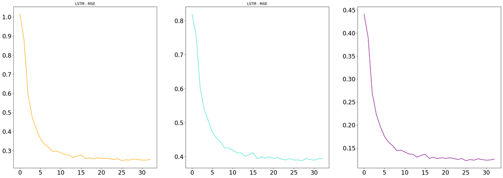

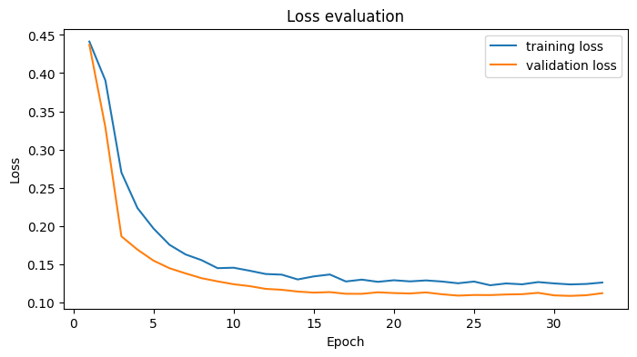

```python
lstm5_history,lstm_model5=model_fits(model5,'LSTM',1e-4,50)
```

**Experiment 6 - Add Batch Normalization Layer**

```python
model6 = Sequential()
model6.add(LSTM(units=32, return_sequences=True, activation='relu', input_shape=(xtrain_combined.shape[1], xtrain_combined.shape[2])))
model6.add(LSTM(units=16, return_sequences=True, activation='relu'))
model6.add(BatchNormalization())
model6.add(Dropout(0.2))
model6.add(LSTM(units=8, return_sequences=True, activation='relu'))
model6.add(Dense(ytrain_combined.shape[1], activation='linear'))
print(model6.summary())
```

```
Model: "sequential_4"
```

```
┏━━━━━━━━━━━━━━━━━━━━━━━━━━━━━━━━━┳━━━━━━━━━━━━━━━━━━━━━━━━┳━━━━━━━━━━━━━━━┓
┃ Layer (type)                    ┃ Output Shape           ┃       Param # ┃
┡━━━━━━━━━━━━━━━━━━━━━━━━━━━━━━━━━╇━━━━━━━━━━━━━━━━━━━━━━━━╇━━━━━━━━━━━━━━━┩
│ lstm_10 (LSTM)                  │ (None, 1, 32)          │         4,608 │
├─────────────────────────────────┼────────────────────────┼───────────────┤
│ lstm_11 (LSTM)                  │ (None, 1, 16)          │         3,136 │
├─────────────────────────────────┼────────────────────────┼───────────────┤
│ batch_normalization             │ (None, 1, 16)          │            64 │
│ (BatchNormalization)            │                        │               │
├─────────────────────────────────┼────────────────────────┼───────────────┤
│ dropout_3 (Dropout)             │ (None, 1, 16)          │             0 │
├─────────────────────────────────┼────────────────────────┼───────────────┤
│ lstm_12 (LSTM)                  │ (None, 1, 8)           │           800 │
├─────────────────────────────────┼────────────────────────┼───────────────┤
│ dense_5 (Dense)                 │ (None, 1, 3)           │            27 │
└─────────────────────────────────┴────────────────────────┴───────────────┘
```

```
 Total params: 8,635 (33.73 KB)
```

```
 Trainable params: 8,603 (33.61 KB)
```

```
 Non-trainable params: 32 (128.00 B)
```

```
None
```

```
1152/1152 ━━━━━━━━━━━━━━━━━━━━ 11s 5ms/step - loss: 0.5344 - mae: 0.9365 - mse: 1.2384 - val_loss: 0.4471 - val_mae: 0.8541 - val_mse: 1.0018
1152/1152 ━━━━━━━━━━━━━━━━━━━━ 10s 4ms/step - loss: 0.5336 - mae: 0.9359 - mse: 1.2347 - val_loss: 0.4505 - val_mae: 0.8584 - val_mse: 1.0099
1152/1152 ━━━━━━━━━━━━━━━━━━━━ 5s 5ms/step - loss: 0.5327 - mae: 0.9353 - mse: 1.2313 - val_loss: 0.4537 - val_mae: 0.8623 - val_mse: 1.0173
1152/1152 ━━━━━━━━━━━━━━━━━━━━ 6s 5ms/step - loss: 0.5320 - mae: 0.9347 - mse: 1.2284 - val_loss: 0.4566 - val_mae: 0.8658 - val_mse: 1.0241
1152/1152 ━━━━━━━━━━━━━━━━━━━━ 5s 4ms/step - loss: 0.5314 - mae: 0.9343 - mse: 1.2259 - val_loss: 0.4593 - val_mae: 0.8689 - val_mse: 1.0304
1152/1152 ━━━━━━━━━━━━━━━━━━━━ 6s 5ms/step - loss: 0.5309 - mae: 0.9339 - mse: 1.2238 - val_loss: 0.4617 - val_mae: 0.8718 - val_mse: 1.0361
1152/1152 ━━━━━━━━━━━━━━━━━━━━ 5s 4ms/step - loss: 0.5304 - mae: 0.9336 - mse: 1.2219 - val_loss: 0.4639 - val_mae: 0.8744 - val_mse: 1.0414
1152/1152 ━━━━━━━━━━━━━━━━━━━━ 7s 6ms/step - loss: 0.5300 - mae: 0.9333 - mse: 1.2203 - val_loss: 0.4659 - val_mae: 0.8768 - val_mse: 1.0462
1152/1152 ━━━━━━━━━━━━━━━━━━━━ 9s 4ms/step - loss: 0.5297 - mae: 0.9331 - mse: 1.2188 - val_loss: 0.4677 - val_mae: 0.8789 - val_mse: 1.0505
1152/1152 ━━━━━━━━━━━━━━━━━━━━ 6s 5ms/step - loss: 0.5294 - mae: 0.9329 - mse: 1.2176 - val_loss: 0.4694 - val_mae: 0.8808 - val_mse: 1.0545
1152/1152 ━━━━━━━━━━━━━━━━━━━━ 11s 6ms/step - loss: 0.5291 - mae: 0.9327 - mse: 1.2165 - val_loss: 0.4709 - val_mae: 0.8826 - val_mse: 1.0581
1152/1152 ━━━━━━━━━━━━━━━━━━━━ 5s 4ms/step - loss: 0.5289 - mae: 0.9326 - mse: 1.2156 - val_loss: 0.4723 - val_mae: 0.8842 - val_mse: 1.0614
1152/1152 ━━━━━━━━━━━━━━━━━━━━ 6s 5ms/step - loss: 0.5287 - mae: 0.9324 - mse: 1.2147 - val_loss: 0.4735 - val_mae: 0.8857 - val_mse: 1.0644
1152/1152 ━━━━━━━━━━━━━━━━━━━━ 5s 5ms/step - loss: 0.5286 - mae: 0.9323 - mse: 1.2140 - val_loss: 0.4747 - val_mae: 0.8870 - val_mse: 1.0672
1152/1152 ━━━━━━━━━━━━━━━━━━━━ 5s 4ms/step - loss: 0.5284 - mae: 0.9322 - mse: 1.2133 - val_loss: 0.4757 - val_mae: 0.8882 - val_mse: 1.0696
1152/1152 ━━━━━━━━━━━━━━━━━━━━ 6s 5ms/step - loss: 0.5283 - mae: 0.9321 - mse: 1.2127 - val_loss: 0.4766 - val_mae: 0.8893 - val_mse: 1.0719
1152/1152 ━━━━━━━━━━━━━━━━━━━━ 5s 4ms/step - loss: 0.5282 - mae: 0.9321 - mse: 1.2122 - val_loss: 0.4775 - val_mae: 0.8903 - val_mse: 1.0739
1152/1152 ━━━━━━━━━━━━━━━━━━━━ 6s 5ms/step - loss: 0.5280 - mae: 0.9320 - mse: 1.2118 - val_loss: 0.4782 - val_mae: 0.8912 - val_mse: 1.0758
1152/1152 ━━━━━━━━━━━━━━━━━━━━ 9s 4ms/step - loss: 0.5280 - mae: 0.9319 - mse: 1.2114 - val_loss: 0.4789 - val_mae: 0.8920 - val_mse: 1.0774
1152/1152 ━━━━━━━━━━━━━━━━━━━━ 6s 5ms/step - loss: 0.5279 - mae: 0.9319 - mse: 1.2110 - val_loss: 0.4795 - val_mae: 0.8927 - val_mse: 1.0789
1152/1152 ━━━━━━━━━━━━━━━━━━━━ 5s 5ms/step - loss: 0.5278 - mae: 0.9318 - mse: 1.2107 - val_loss: 0.4801 - val_mae: 0.8934 - val_mse: 1.0803
1152/1152 ━━━━━━━━━━━━━━━━━━━━ 10s 5ms/step - loss: 0.5277 - mae: 0.9318 - mse: 1.2104 - val_loss: 0.4806 - val_mae: 0.8940 - val_mse: 1.0816
1152/1152 ━━━━━━━━━━━━━━━━━━━━ 6s 6ms/step - loss: 0.5277 - mae: 0.9317 - mse: 1.2101 - val_loss: 0.4811 - val_mae: 0.8945 - val_mse: 1.0827
Epoch 23: early stopping
Restoring model weights from the end of the best epoch: 16.

Model:LSTM
```

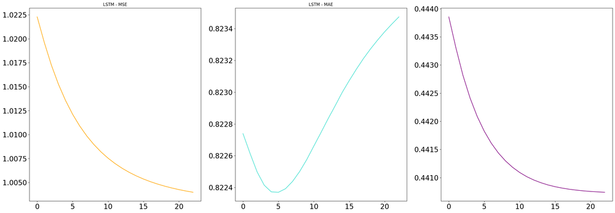

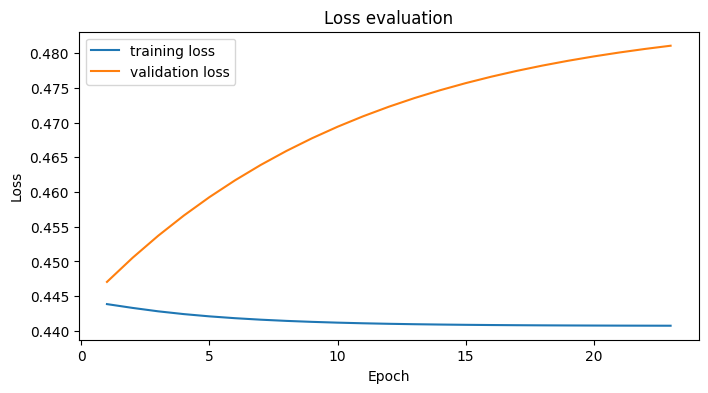

```python
lstm6_history,lstm_model6=model_fits(model6,'LSTM',1e-4,50)
```

```python
# learning rate schedule
import math
def step_decay(epoch):
        initial_lrate = 0.1
        drop = 0.5
        epochs_drop = 10.0
        lrate = initial_lrate * math.pow(drop, math.floor((1+epoch)/epochs_drop))
        return lrate
sgd = SGD(learning_rate=0.0, momentum=0.9)
# learning schedule callback
lrate = LearningRateScheduler(step_decay)
callbacks_list = [lrate]
early_stopping=tf.keras.callbacks.EarlyStopping(monitor='loss',patience=7,verbose=1,restore_best_weights='True',min_delta=0.0001,start_from_epoch=10)
# Fit the model
model7=base_model.compile(optimizer=optimizer,loss=tf.keras.losses.Huber(),metrics=['mse','mae'])
history7=base_model.fit(xtrain_combined,y=ytrain_combined,shuffle=False, epochs=50, batch_size=1, validation_data=(xval_combined, yval_combined),callbacks=[lrate,early_stopping], verbose=2)
print('')
print(f"Model7:")
```

```
1152/1152 - 9s - 8ms/step - loss: 0.2058 - mae: 0.5223 - mse: 0.4431 - val_loss: 0.5538 - val_mae: 0.9755 - val_mse: 1.2666 - learning_rate: 0.1000
1152/1152 - 9s - 8ms/step - loss: 0.2031 - mae: 0.5178 - mse: 0.4323 - val_loss: 0.6085 - val_mae: 1.0340 - val_mse: 1.4141 - learning_rate: 0.1000
1152/1152 - 5s - 5ms/step - loss: 0.2023 - mae: 0.5163 - mse: 0.4302 - val_loss: 0.6230 - val_mae: 1.0499 - val_mse: 1.4546 - learning_rate: 0.1000
1152/1152 - 9s - 8ms/step - loss: 0.2020 - mae: 0.5158 - mse: 0.4295 - val_loss: 0.6273 - val_mae: 1.0547 - val_mse: 1.4666 - learning_rate: 0.1000
1152/1152 - 6s - 5ms/step - loss: 0.2020 - mae: 0.5156 - mse: 0.4293 - val_loss: 0.6286 - val_mae: 1.0561 - val_mse: 1.4702 - learning_rate: 0.1000
1152/1152 - 4s - 4ms/step - loss: 0.2019 - mae: 0.5156 - mse: 0.4293 - val_loss: 0.6290 - val_mae: 1.0565 - val_mse: 1.4713 - learning_rate: 0.1000
1152/1152 - 6s - 5ms/step - loss: 0.2019 - mae: 0.5156 - mse: 0.4293 - val_loss: 0.6291 - val_mae: 1.0567 - val_mse: 1.4717 - learning_rate: 0.1000
1152/1152 - 9s - 8ms/step - loss: 0.2019 - mae: 0.5156 - mse: 0.4293 - val_loss: 0.6292 - val_mae: 1.0567 - val_mse: 1.4718 - learning_rate: 0.1000
1152/1152 - 5s - 5ms/step - loss: 0.2019 - mae: 0.5156 - mse: 0.4293 - val_loss: 0.6292 - val_mae: 1.0567 - val_mse: 1.4718 - learning_rate: 0.1000
1152/1152 - 4s - 4ms/step - loss: 0.2010 - mae: 0.5139 - mse: 0.4227 - val_loss: 0.8336 - val_mae: 1.2807 - val_mse: 2.0894 - learning_rate: 0.0500
1152/1152 - 5s - 4ms/step - loss: 0.1987 - mae: 0.5109 - mse: 0.4176 - val_loss: 0.8332 - val_mae: 1.2803 - val_mse: 2.0883 - learning_rate: 0.0500
1152/1152 - 5s - 4ms/step - loss: 0.1987 - mae: 0.5109 - mse: 0.4176 - val_loss: 0.8331 - val_mae: 1.2802 - val_mse: 2.0880 - learning_rate: 0.0500
1152/1152 - 4s - 4ms/step - loss: 0.1986 - mae: 0.5108 - mse: 0.4175 - val_loss: 0.8331 - val_mae: 1.2802 - val_mse: 2.0878 - learning_rate: 0.0500
1152/1152 - 6s - 5ms/step - loss: 0.1986 - mae: 0.5108 - mse: 0.4175 - val_loss: 0.8331 - val_mae: 1.2802 - val_mse: 2.0878 - learning_rate: 0.0500
1152/1152 - 10s - 9ms/step - loss: 0.1986 - mae: 0.5108 - mse: 0.4175 - val_loss: 0.8331 - val_mae: 1.2802 - val_mse: 2.0878 - learning_rate: 0.0500
1152/1152 - 5s - 4ms/step - loss: 0.1986 - mae: 0.5108 - mse: 0.4175 - val_loss: 0.8331 - val_mae: 1.2802 - val_mse: 2.0878 - learning_rate: 0.0500
1152/1152 - 4s - 4ms/step - loss: 0.1986 - mae: 0.5108 - mse: 0.4175 - val_loss: 0.8331 - val_mae: 1.2802 - val_mse: 2.0878 - learning_rate: 0.0500
1152/1152 - 6s - 5ms/step - loss: 0.1986 - mae: 0.5108 - mse: 0.4175 - val_loss: 0.8331 - val_mae: 1.2802 - val_mse: 2.0878 - learning_rate: 0.0500
Epoch 18: early stopping
Restoring model weights from the end of the best epoch: 11.

Model7:
```